# Soil origin affects gut microbiota and immune response in a wild rodent - metataxonomic analysis

2025-10-13

```r
rm(list=ls())
```

```r
library(tidyverse) # For utilities
library(microeco) # Analysis framework
library(rbiom) # To load the ASV table
library(ape) # read tree
library(vegan)
library(pairwiseAdonis)
library(cowplot)
library(phyloseq)
library(ggsignif)
library(file2meco) # meco<->physeq data conversions
library(lme4) # LMMs
library(lmerTest) # LMM p-values
library(MuMIn) # marginal and conditional R2 for LMMs
library(rstatix) # Extension for basic statistic tests
library(Rmisc) # Summary statistics
library(ggbreak) # Axis breaks for ggplot
library(FSA) # For some tests
library(glue) # String manipulation for filenames
library(microViz) # fix taxonomy table ranks
library(scales) # ggplot text wrap functionality
```

To use these data, start with fully running all code chunks under **Data preparation.** You can then move to any other section.

# Data preparation

## Load data

```r
# Load ITS2 data
asv_table <- read.table("data_analysis/feature-table_ITS2_c97.tsv", sep = "\t", header=TRUE, row.names = 1)
Metadata <- read.csv("data_analysis/metadata_ITS2_c97.tsv", sep = "\t", row.names = 1, na.strings = "NA")
taxa <- read.csv("data_analysis/taxonomy_ITS2_c97.guilds.txt", header = TRUE,
                 sep = "\t",
                 row.names = 1,
                 na.strings = c("","NA"))


# Microeco object
dsF <- microtable$new(sample_table = Metadata,
                      otu_table = asv_table,
                      tax_table = taxa,
                      )
```

```
## 1 samples with 0 abundance are removed from the otu_table ...
```

```r
dsF
```

```
## microtable-class object:
## sample_table have 199 rows and 29 columns
## otu_table have 2502 rows and 198 columns
## tax_table have 2502 rows and 17 columns
```

```r
dsF$tidy_dataset()
# make the taxonomic information unified
dsF$tax_table <- dsF$tax_table %>% tidy_taxonomy
print(dsF)
```

```
## microtable-class object:
## sample_table have 198 rows and 29 columns
## otu_table have 2502 rows and 198 columns
## tax_table have 2502 rows and 17 columns
```

```r
# Load tip-agglomerated 16S data
# Load 16S data
asv_table <- read.table("data_analysis/feature-table_16S.tsv", sep = "\t", header=TRUE, row.names = 1)
Metadata <- read.csv("data_analysis/metadata_feces-soil_16S.txt", sep = "\t", row.names = 1, na.strings = "NA")
taxa <- read.csv("data_analysis/taxonomy_16S.tsv", header = TRUE, sep = "\t", row.names = 1, ,
                 na.strings = c("","NA"))
tree <- ape::read.tree("data_analysis/rooted-tree_16S.nwk") # Tree is rooted

# Microeco object
dsB <- microtable$new(sample_table = Metadata,
                      otu_table = asv_table,
                      tax_table = taxa,
                      phylo_tree = tree)
```

```
## 1 samples with 0 abundance are removed from the otu_table ...
```

```r
dsB
```

```
## microtable-class object:
## sample_table have 205 rows and 24 columns
## otu_table have 6125 rows and 204 columns
## tax_table have 6125 rows and 7 columns
## phylo_tree have 6125 tips
```

```r
dsB$tidy_dataset()
# make the taxonomic information unified, very important
dsB$tax_table <- dsB$tax_table %>% tidy_taxonomy

print(dsB)
```

```
## microtable-class object:
## sample_table have 204 rows and 24 columns
## otu_table have 6125 rows and 204 columns
## tax_table have 6125 rows and 7 columns
## phylo_tree have 6125 tips
```

## Clean 16S data

```r
head(dsB$tax_table)
```

|  | Kingdom | Phylum | Class | Order | Family | Genus | Species |
| --- | --- | --- | --- | --- | --- | --- | --- |
| 729f8f15dc13862f0e1e9e1a464d34cf | k__Bacteria | p__Bacteroidota | c__Bacteroidia | o__Bacteroidales | f__Muribaculaceae | g__ | s__ |
| b14ffe0d5f01d4815469d35ed25503c3 | k__Bacteria | p__Actinomycetota | c__Actinomycetes | o__Actinomycetales | f__Bifidobacteriaceae | g__Bifidobacterium_388775 | s__Bifidobacterium globosum |
| 39ae9ec4897d2cb8d9497b0ef712933e | k__Bacteria | p__Bacillota_I | c__Bacilli_A | o__Lactobacillales | f__Lactobacillaceae | g__Lactobacillus | s__ |
| c30f3712e5c74df60710c676e73b0187 | k__Bacteria | p__Bacillota_I | c__Bacilli_A | o__Lactobacillales | f__Lactobacillaceae | g__Lactobacillus | s__ |
| 7362b45f4fb09a66a0a81039b01098ba | k__Bacteria | p__Bacillota_I | c__Bacilli_A | o__Lactobacillales | f__Lactobacillaceae | g__Lactobacillus | s__Lactobacillus rodentium |
| 3ba8e2478f76b09d44aed21eeb65440e | k__Bacteria | p__Bacillota_I | c__Bacilli_A | o__Lactobacillales | f__Lactobacillaceae | g__Lactobacillus | s__ |

```r
dsB$tax_table <- dsB$tax_table %>% base::subset(Kingdom == "k__Bacteria")
# This will remove the lines containing the taxa word regardless of taxonomic ranks and ignoring word case in the tax_table.
# So if you want to filter some taxa not considerd pollutions, please use subset like the previous operation to filter tax_table.
dsB$filter_pollution(taxa = c("mitochondria", "chloroplast"))
```

```
## Total 44 features are removed from tax_table ...
```

## Clean ITS2 data

Filter only to k__Fungi

```r
# use R subset function to filter taxa in tax_table
dsF$tax_table <- dsF$tax_table %>% base::subset(Kingdom == "k__Fungi")
dsF$tidy_dataset()
print(dsF)
```

```
## microtable-class object:
## sample_table have 198 rows and 29 columns
## otu_table have 2062 rows and 198 columns
## tax_table have 2062 rows and 17 columns
```

## Subset

Subset by sample type and check library sizes for rarefaction

```r
# ITS2
dsF$sample_sums() %>% sort()
```

```
##     extr.neg2      SG44B.F2      SG37B.F1      SG51B.F1     extr.neg1
##           119           168           940          1012          1211
##       SG7A.F1      SG15A.F1      SG36B.F1      SG29B.F1      SG60A.F1
##          1410          2254          2618          2639          3344
##      SG13A.F2      SG41A.F2      SG17B.F1      SG23A.F1      SG40A.F1
##          4870          4982          5605          6260          6616
##      SG20A.F1      SG27A.F2      SG84A.F1     SG105A.F2     SG102A.F2
##          6729          7146          7782          7917          7931
##     SG107B.F2      SG31A.F1      SG27A.F1     SG107B.F1      SG69A.F2
##          7969          8140          8251          8482          8535
##      SG98A.F1      SG41A.F1      SG34A.F1      SG47A.F2      SG53B.F1
##          8620          9117          9384          9578          9606
##      SG28B.F1      SG13A.F1      SG33B.F1      SG60A.F2      SG57B.F2
##         10067         10776         10879         11170         11382
##      SG44B.F1      SG35A.F2       SG3B.F1      SG79A.F2      SG40A.F2
##         11540         11730         11947         12468         12699
##      SG39A.F2       SG3B.F2      SG19A.F1      SG95A.F1      SG55B.F2
##         12844         12852         12863         13019         13102
##      SG62A.F2      SG26A.F2      SG84A.F2     SG103B.F2       SG4A.F1
##         13433         14063         14366         14640         14749
##      SG52A.F1      SG85B.F2      SG76A.F1      SG59A.F2      SG96B.F2
##         14768         14833         14869         14892         14914
##      SG46A.F2     SG106B.F2      SG24A.F2      SG24A.F1      SG56B.F2
##         14945         14997         15049         15123         15263
##      SG42B.F2       SG9B.F1      SG73A.F2      SG49B.F1      SG14B.F2
##         15453         15851         16104         16110         16167
##      SG37B.F2      SG89A.F2     SG104A.F2      SG25B.F2      SG34A.F2
##         16267         16285         16326         16348         16364
##      SG55B.F1      SG32B.F2      SG10B.F1       SG6B.F2      SG78A.F2
##         16390         16463         16854         16861         17229
##      SG68A.F2      SG68A.F1      SG10B.F2      SG45B.F1   SG102A.F1.1
##         17421         17431         17469         17472         17581
##       SG2A.F2      SG61A.F1      SG33B.F2 SGsource.food      SG22A.F1
##         17713         17748         18034         18095         18241
##      SG91A.F2      SG94B.F2      SG53B.F2      SG47A.F1      SG42B.F1
##         18272         18468         18561         18719         18894
##     SG101A.F1      SG20A.F2      SG79A.F1       SG7A.F2      SG48B.F2
##         18915         19027         19092         19262         19493
##      SG23A.F2      SG80B.F1      SG50A.F2      SG26A.F1     SG108B.F2
##         19728         20141         20161         20196         20675
```

[output cut: 25 more lines]

```
##         44799         45706         45945         47241         49085
##      SGPhak.2       SG5A.F1      SG45B.F2     SG109B.F1      SG51B.F2
##         49798         50076         52889         53664         54518
##      SG59A.F1       SG8A.F1      SG96B.F1      SG11A.F2       SGMik.2
##         54871         58040         58259         59674         61086
##      SG21B.F2         SG16B     SGLmaki.1     SG108B.F1     SG104A.F1
##         61453         62622         67809         68122         73580
##       SG1A.F1       SG8A.F2      SG97B.F1      SG11A.F1     SGKvesi.1
##         76547         80377         81925         82030         86846
##       SGMik.1       SGJKL.1      SG30B.F1       SGJKL.2      SG43B.F1
##         91242         91843         97965         98125         98884
##      SGPhak.1      SG69A.F1       SGKuo.2       SGKuo.1      SG94B.F1
##        101178        104617        113585        125318        125377
##       SG2A.F1     SGKvesi.2      SG50A.F1
##        127358        130872        190701
```

```r
dsFSoil <- clone(dsF)
dsFSoil$sample_table <- dsFSoil$sample_table %>% subset(Sample_type == "treatment_soil")
dsFSoil$tidy_dataset()
```

```
## 378 taxa with 0 abundance are removed from the otu_table ...
```

```r
dsFSoil$sample_sums() %>% sort()
```

```
## SGLmaki.2  SGPhak.2   SGMik.2 SGLmaki.1 SGKvesi.1   SGMik.1   SGJKL.1   SGJKL.2
##     34549     49798     61086     67809     86846     91242     91843     98125
##  SGPhak.1   SGKuo.2   SGKuo.1 SGKvesi.2
##    101178    113585    125318    130872
```

```r
dsFFec <- clone(dsF)
dsFFec$sample_table <- dsFFec$sample_table %>% subset(Sample_type == "fecal_community")
dsFFec$tidy_dataset()
```

```
## 1155 taxa with 0 abundance are removed from the otu_table ...
```

```r
dsFFec$sample_sums() %>% sort()
```

```
##    SG44B.F2    SG37B.F1    SG51B.F1     SG7A.F1    SG15A.F1    SG36B.F1
##         168         940        1012        1410        2254        2618
##    SG29B.F1    SG60A.F1    SG13A.F2    SG41A.F2    SG17B.F1    SG23A.F1
##        2639        3344        4870        4982        5605        6260
##    SG40A.F1    SG20A.F1    SG27A.F2    SG84A.F1   SG105A.F2   SG102A.F2
##        6616        6729        7146        7782        7917        7931
##   SG107B.F2    SG31A.F1    SG27A.F1   SG107B.F1    SG69A.F2    SG98A.F1
##        7969        8140        8251        8482        8535        8620
##    SG41A.F1    SG34A.F1    SG47A.F2    SG53B.F1    SG28B.F1    SG13A.F1
##        9117        9384        9578        9606       10067       10776
##    SG33B.F1    SG60A.F2    SG57B.F2    SG44B.F1    SG35A.F2     SG3B.F1
##       10879       11170       11382       11540       11730       11947
##    SG79A.F2    SG40A.F2    SG39A.F2     SG3B.F2    SG19A.F1    SG95A.F1
##       12468       12699       12844       12852       12863       13019
##    SG55B.F2    SG62A.F2    SG26A.F2    SG84A.F2   SG103B.F2     SG4A.F1
##       13102       13433       14063       14366       14640       14749
##    SG52A.F1    SG85B.F2    SG76A.F1    SG59A.F2    SG96B.F2    SG46A.F2
##       14768       14833       14869       14892       14914       14945
##   SG106B.F2    SG24A.F2    SG24A.F1    SG56B.F2    SG42B.F2     SG9B.F1
##       14997       15049       15123       15263       15453       15851
##    SG73A.F2    SG49B.F1    SG14B.F2    SG37B.F2    SG89A.F2   SG104A.F2
##       16104       16110       16167       16267       16285       16326
##    SG25B.F2    SG34A.F2    SG55B.F1    SG32B.F2    SG10B.F1     SG6B.F2
##       16348       16364       16390       16463       16854       16861
##    SG78A.F2    SG68A.F2    SG68A.F1    SG10B.F2    SG45B.F1 SG102A.F1.1
##       17229       17421       17431       17469       17472       17581
##     SG2A.F2    SG61A.F1    SG33B.F2    SG22A.F1    SG91A.F2    SG94B.F2
##       17713       17748       18034       18241       18272       18468
##    SG53B.F2    SG47A.F1    SG42B.F1   SG101A.F1    SG20A.F2    SG79A.F1
##       18561       18719       18894       18915       19027       19092
##     SG7A.F2    SG48B.F2    SG23A.F2    SG80B.F1    SG50A.F2    SG26A.F1
##       19262       19493       19728       20141       20161       20196
##   SG108B.F2    SG52A.F2    SG91A.F1   SG101A.F2    SG43B.F2    SG36B.F2
##       20675       20873       21111       21113       21131       21329
##    SG54A.F2     SG9B.F2    SG98A.F2     SG1A.F2    SG28B.F2   SG105A.F1
##       21353       21614       21726       22159       22257       22283
##    SG30B.F2    SG61A.F2    SG19A.F2    SG72A.F2   SG100B.F2    SG46A.F1
##       22379       22790       23153       23373       23493       23976
##    SG22A.F2    SG83A.F2    SG75B.F2    SG97B.F2    SG17B.F2    SG18A.F1
##       24059       24081       24186       24425       24856       25191
##    SG72A.F1    SG25B.F1    SG39A.F1    SG76A.F2    SG74A.F2    SG31B.F1
##       25406       25646       25817       25920       26118       26231
##    SG15A.F2    SG86A.F2    SG95A.F2    SG54A.F1    SG63B.F2    SG86A.F1
##       26806       27265       27309       27361       27613       27791
##    SG12A.F2    SG48B.F1    SG90A.F1    SG64B.F2    SG92B.F2    SG90A.F2
##       28016       29275       29465       29609       29862       29887
##    SG99A.F2    SG78A.F1     SG4A.F2    SG80B.F2   SG109B.F2    SG12A.F1
##       29913       30345       30371       31493       32376       32388
##    SG92B.F1    SG38A.F1   SG106B.F1     SG6B.F1    SG32B.F1    SG29B.F2
##       32570       33539       34807       35941       36663       36729
##    SG56B.F1    SG73A.F1    SG31B.F2     SG5A.F2    SG35A.F1    SG74A.F1
##       37467       37484       38831       39238       39849       40413
##    SG38A.F2    SG14B.F1    SG99A.F1    SG82A.F2    SG18A.F2     SG5A.F1
##       44799       45706       45945       47241       49085       50076
##    SG45B.F2   SG109B.F1    SG51B.F2    SG59A.F1     SG8A.F1    SG96B.F1
##       52889       53664       54518       54871       58040       58259
##    SG11A.F2    SG21B.F2       SG16B   SG108B.F1   SG104A.F1     SG1A.F1
##       59674       61453       62622       68122       73580       76547
##     SG8A.F2    SG97B.F1    SG11A.F1    SG30B.F1    SG43B.F1    SG69A.F1
##       80377       81925       82030       97965       98884      104617
##    SG94B.F1     SG2A.F1    SG50A.F1
##      125377      127358      190701
```

```r
# 16S
dsB$sample_sums() %>% sort()
```

```
##   SGsoil.extr.neg           SG7A.F2     SGF.extr.neg2      SGF.pcr.neg1
##                 2                 7                 7                15
##    SGsource.nest1 SGsource.bedding1      SGF.pcr.neg2         SG108B.F1
##                18               301               306              5621
##          SGPhak.1           SGJKL.1           SGMik.2           SGKuo.2
##              7658              9530              9615              9624
##          SG36B.F1         SGKvesi.2           SGJKL.2          SGF.mock
##              9842              9873             10628             10712
##             SG16B          SG17B.F1           SGKuo.1          SG14B.F2
##             11232             11495             11730             11758
##         SG106B.F2          SG28B.F2          SG43B.F2          SG22A.F1
##             12122             12156             12307             12408
##         SGLmaki.2          SG94B.F1          SG38A.F2           SGMik.1
##             12481             12519             12591             12658
##          SG59A.F2           SG4A.F1         SG101A.F1           SG3B.F2
##             12710             12798             12926             12978
##         SGLmaki.1          SG56B.F1          SG19A.F1          SG86A.F2
##             12990             13042             13154             13168
##           SG5A.F1          SG12A.F2         SG100B.F2          SG20A.F2
##             13438             13440             13471             13880
##          SGPhak.2          SG98A.F1          SG23A.F2          SG22A.F2
##             14137             14227             14242             14356
##          SG55B.F1          SG47A.F2          SG69A.F2          SG24A.F1
##             14450             14579             14641             14646
##          SG25B.F2          SG20A.F1          SG15A.F1           SG7A.F1
##             14659             14795             14870             14909
##         SGKvesi.1          SG13A.F1          SG27A.F2          SG47A.F1
##             14937             14997             15074             15104
##     SGF.extr.neg1         SG101A.F2          SG25B.F1          SG32B.F2
##             15203             15238             15261             15369
##          SG59A.F1         SG104A.F2          SG54A.F2          SG68A.F2
##             15409             15541             15563             15601
##          SG91A.F1          SG10B.F2          SG39A.F2          SG33B.F1
##             15606             15644             15724             15767
##          SG15A.F2          SG30B.F2          SG11A.F2          SG76A.F1
##             15771             15811             15812             15856
##           SG6B.F1          SG34A.F1          SG78A.F1          SG18A.F2
##             15918             16025             16088             16179
##          SG56B.F2          SG17B.F2         SG105A.F1          SG40A.F1
##             16191             16214             16238             16255
```

[output cut: 47 more lines]

```
##             21443             21447             21482             21499
##         SG106B.F1          SG64B.F2          SG37B.F2          SG99A.F1
##             21551             21725             21773             21773
##          SG35A.F2          SG52A.F2          SG12A.F1           SG2A.F2
##             21781             21978             21984             22221
##           SG2A.F1          SG24A.F2          SG14B.F1          SG95A.F1
##             22259             22456             22605             22938
##          SG19A.F2          SG97B.F2          SG90A.F2          SG91A.F2
##             22985             23132             23411             23488
##          SG36B.F2          SG13A.F2          SG23A.F1          SG29B.F2
##             24215             24390             24463             24576
##          SG61A.F1          SG33B.F2          SG51B.F1          SG40A.F2
##             24944             24965             25104             26267
##          SG97B.F1          SG76A.F2          SG72A.F1          SG37B.F1
##             27467             27832             28167             30582
```

```r
# Soil ASVs
dsBSoil <- clone(dsB)
dsBSoil$sample_table <- dsBSoil$sample_table %>% subset(Sample_type == "treatment_soil")
dsBSoil$tidy_dataset()
```

```
## 3159 taxa with 0 abundance are removed from the otu_table ...
```

```r
dsBSoil$sample_sums() %>% sort()
```

```
##  SGPhak.1   SGJKL.1   SGKuo.2   SGMik.2 SGKvesi.2   SGJKL.2   SGKuo.1 SGLmaki.2
##      7631      9516      9526      9609      9861     10615     11643     12440
##   SGMik.1 SGLmaki.1  SGPhak.2 SGKvesi.1
##     12640     12975     14059     14900
```

```r
# Fecal ASVs
dsBFec <- clone(dsB)
dsBFec$sample_table <- dsBFec$sample_table %>% subset(Sample_type == "fecal_community")
dsBFec$tidy_dataset()
```

```
## 2993 taxa with 0 abundance are removed from the otu_table ...
```

```r
dsBFec$sample_sums() %>% sort()
```

```
##     SG7A.F2   SG108B.F1    SG36B.F1       SG16B    SG17B.F1    SG14B.F2
##           7        5621        9842       11232       11495       11754
##   SG106B.F2    SG28B.F2    SG43B.F2    SG22A.F1    SG94B.F1    SG38A.F2
##       12118       12156       12307       12408       12519       12591
##    SG59A.F2     SG4A.F1   SG101A.F1     SG3B.F2    SG56B.F1    SG19A.F1
##       12703       12780       12926       12965       13042       13154
##    SG86A.F2     SG5A.F1    SG12A.F2   SG100B.F2    SG20A.F2    SG98A.F1
##       13162       13438       13440       13471       13880       14227
##    SG23A.F2    SG22A.F2    SG55B.F1    SG47A.F2    SG69A.F2    SG24A.F1
##       14242       14353       14450       14579       14641       14646
##    SG25B.F2    SG20A.F1    SG15A.F1     SG7A.F1    SG13A.F1    SG27A.F2
##       14652       14795       14870       14906       14988       15074
##    SG47A.F1   SG101A.F2    SG25B.F1    SG32B.F2    SG59A.F1    SG54A.F2
##       15104       15238       15261       15359       15409       15520
##   SG104A.F2    SG91A.F1    SG68A.F2    SG10B.F2    SG39A.F2    SG15A.F2
##       15541       15600       15601       15641       15724       15761
##    SG33B.F1    SG30B.F2    SG11A.F2    SG76A.F1     SG6B.F1    SG34A.F1
##       15767       15811       15812       15856       15918       16025
##    SG78A.F1    SG18A.F2    SG56B.F2    SG17B.F2   SG105A.F1    SG85B.F2
##       16088       16179       16187       16214       16238       16249
##    SG40A.F1    SG74A.F2    SG46A.F2    SG31B.F2    SG42B.F1    SG26A.F2
##       16253       16281       16434       16484       16592       16642
##   SG108B.F2    SG72A.F2   SG102A.F2    SG50A.F1    SG49B.F1    SG26A.F1
##       16742       16754       16814       16881       16892       16905
##     SG1A.F2     SG3B.F1    SG52A.F1    SG27A.F1    SG11A.F1    SG28B.F1
##       16928       16975       16977       17017       17072       17158
##    SG18A.F1    SG74A.F1    SG29B.F1    SG92B.F2     SG9B.F1    SG10B.F1
##       17177       17210       17219       17503       17513       17521
##    SG44B.F2    SG38A.F1    SG31B.F1    SG45B.F2    SG35A.F1   SG107B.F2
##       17609       17629       17711       17748       17754       17759
##    SG60A.F1    SG80B.F1   SG107B.F1    SG32B.F1    SG99A.F2 SG102A.F1.1
##       17779       17857       17903       17912       17923       18007
##    SG46A.F1    SG44B.F1    SG84A.F1   SG109B.F2   SG103B.F2    SG21B.F2
##       18036       18094       18204       18333       18359       18425
##    SG42B.F2    SG83A.F2    SG84A.F2    SG96B.F2    SG54A.F1    SG41A.F1
##       18527       18545       18640       18711       18732       18790
##     SG8A.F1     SG6B.F2    SG92B.F1    SG50A.F2    SG31A.F1     SG9B.F2
##       18793       18797       18820       18982       19014       19080
##    SG30B.F1    SG82A.F2    SG45B.F1    SG78A.F2    SG55B.F2    SG43B.F1
##       19107       19140       19164       19192       19209       19261
##    SG95A.F2    SG86A.F1     SG4A.F2   SG109B.F1    SG68A.F1    SG79A.F2
##       19327       19443       19464       19595       19596       19701
##    SG90A.F1    SG94B.F2    SG73A.F1    SG41A.F2    SG73A.F2    SG79A.F1
##       19727       19783       19881       19898       20042       20044
##    SG60A.F2    SG34A.F2    SG61A.F2     SG5A.F2    SG48B.F1    SG51B.F2
##       20127       20204       20381       20410       20433       20471
##   SG105A.F2     SG1A.F1    SG75B.F2    SG89A.F2    SG96B.F1    SG57B.F2
##       20583       20611       20691       20728       20791       20806
##    SG53B.F1    SG39A.F1    SG53B.F2   SG104A.F1     SG8A.F2    SG48B.F2
##       20846       20851       20984       21052       21098       21216
##    SG62A.F2    SG98A.F2    SG80B.F2    SG63B.F2    SG69A.F1   SG106B.F1
##       21281       21443       21447       21470       21499       21551
##    SG37B.F2    SG64B.F2    SG99A.F1    SG35A.F2    SG52A.F2    SG12A.F1
##       21712       21725       21773       21781       21978       21984
##     SG2A.F2     SG2A.F1    SG24A.F2    SG14B.F1    SG95A.F1    SG19A.F2
##       22218       22259       22440       22605       22938       22985
##    SG97B.F2    SG90A.F2    SG91A.F2    SG36B.F2    SG13A.F2    SG23A.F1
##       23062       23411       23488       24215       24390       24463
##    SG29B.F2    SG61A.F1    SG33B.F2    SG51B.F1    SG40A.F2    SG97B.F1
##       24576       24944       24954       25104       26267       27467
##    SG76A.F2    SG72A.F1    SG37B.F1
##       27832       28167       30575
```

## Rename variables

```r
dsFFec$sample_table$Sampling_timepoint <- factor(dsFFec$sample_table$Sampling_timepoint,
                                  levels = c("T1", "T2"),
                                  labels = c("Pre", "Post"))
dsBFec$sample_table$Sampling_timepoint <- factor(dsBFec$sample_table$Sampling_timepoint,
                                  levels = c("T1", "T2"),
                                  labels = c("Pre", "Post"))
```

## Rarefaction

### ITS2

Check rarefaction curves

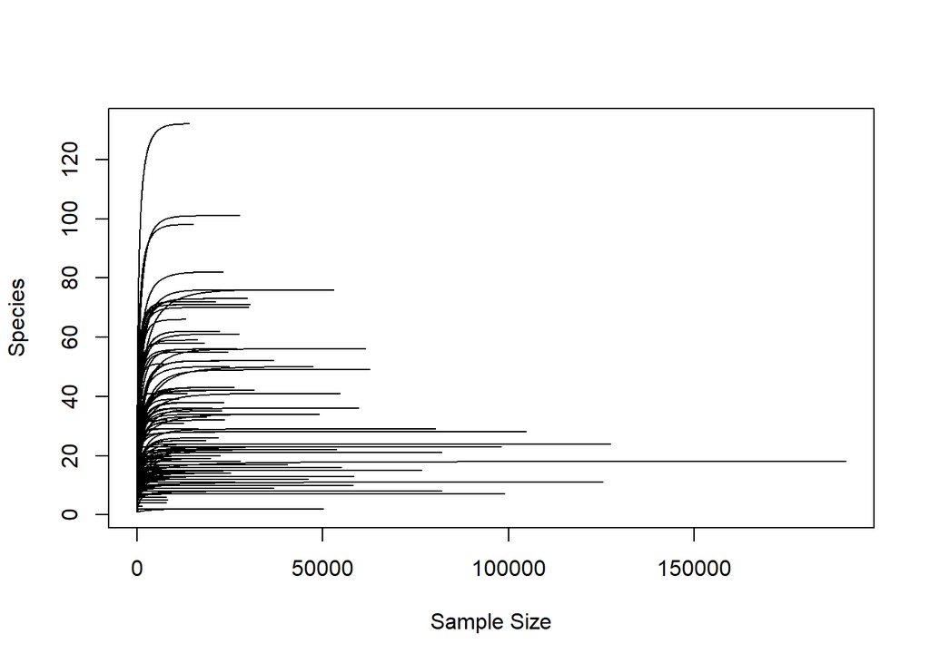

```r
# We use vegan for rarefaction curves, so you need to tweak the otu_table in a phyloseq object a little:
tab <- dsFFec$otu_table %>% as.matrix() %>% t()
## you get a warning here, but this is what we need to have
rarecurve(tab, step=20, cex=0.5, label = FALSE) # make rarefaction curves
```

Curves mostly plateau before 10k lib size.

```r
dsFFec_unrar <- clone(dsFFec) # Make an unrarefied clone of fecal data for later

dsFSoil$rarefy_samples(sample.size = 34549) # Lowest sample size
```

```
## 45 features are removed because they are no longer present in any sample after random subsampling ...
```

```
## 45 taxa with 0 abundance are removed from the otu_table ...
```

```r
dsFFec$rarefy_samples(sample.size = 8251) # Losing quite many samples here, especially at T1
```

```
## 20 samples are removed because of fewer reads than input sample.size ...
```

```
## 18 taxa with 0 abundance are removed from the otu_table ...
```

```
## 18 features with 0 abundance are removed after filtering samples ...
```

```
## 15 features are removed because they are no longer present in any sample after random subsampling ...
```

```
## 15 taxa with 0 abundance are removed from the otu_table ...
```

### 16S

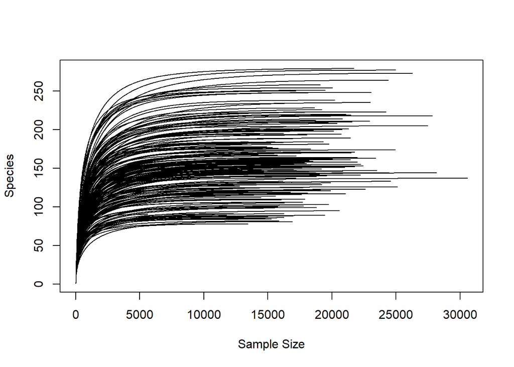

```r
tab <- dsBFec$otu_table %>% as.matrix() %>% t()
rarecurve(tab, step=20, cex=0.5, label = FALSE)
```

```r
dsBFec_unrar <- clone(dsBFec)
dsBSoil$rarefy_samples(sample.size = 7631)
```

```
## 82 features are removed because they are no longer present in any sample after random subsampling ...
```

```
## 82 taxa with 0 abundance are removed from the otu_table ...
```

```r
dsBFec$rarefy_samples(sample.size = 11232)
```

```
## 3 samples are removed because of fewer reads than input sample.size ...
```

```
## 3 taxa with 0 abundance are removed from the otu_table ...
```

```
## 3 features with 0 abundance are removed after filtering samples ...
```

```
## 114 features are removed because they are no longer present in any sample after random subsampling ...
```

```
## 114 taxa with 0 abundance are removed from the otu_table ...
```

## Tally samples

```r
dsFFec$sample_table %>%
  group_by(Sampling_timepoint) %>%
  tally()
```

| Sampling_timepoint | n |
| --- | --- |
| Pre | 73 |
| Post | 90 |

```r
dsFFec$sample_table %>%
  group_by(Sampling_timepoint, Soil_type) %>%
  tally()
```

| Sampling_timepoint | Soil_type | n |
| --- | --- | --- |
| Pre | Control | 17 |
| Pre | Park | 30 |
| Pre | Urban | 26 |
| Post | Control | 20 |
| Post | Park | 36 |
| Post | Urban | 34 |

```r
dsBFec$sample_table %>%
  group_by(Sampling_timepoint) %>%
  tally()
```

| Sampling_timepoint | n |
| --- | --- |
| Pre | 84 |
| Post | 96 |

```r
dsBFec$sample_table %>%
  group_by(Sampling_timepoint, Soil_type) %>%
  tally()
```

| Sampling_timepoint | Soil_type | n |
| --- | --- | --- |
| Pre | Control | 21 |
| Pre | Park | 34 |
| Pre | Urban | 29 |
| Post | Control | 21 |
| Post | Park | 38 |
| Post | Urban | 37 |

## Subset by timepoint

```r
dsFFecT2 <- clone(dsFFec)
dsFFecT2$sample_table <- dsFFecT2$sample_table %>% subset(Sampling_timepoint == "Post")
dsFFecT2$tidy_dataset()
```

```
## 81 taxa with 0 abundance are removed from the otu_table ...
```

```r
dsFFecT1 <- clone(dsFFec)
dsFFecT1$sample_table <- dsFFecT1$sample_table %>% subset(Sampling_timepoint == "Pre")
dsFFecT1$tidy_dataset()
```

```
## 721 taxa with 0 abundance are removed from the otu_table ...
```

```r
dsBFecT2 <- clone(dsBFec)
dsBFecT2$sample_table <- dsBFecT2$sample_table %>% subset(Sampling_timepoint == "Post")
dsBFecT2$tidy_dataset()
```

```
## 503 taxa with 0 abundance are removed from the otu_table ...
```

```r
dsBFecT1 <- clone(dsBFec)
dsBFecT1$sample_table <- dsBFecT1$sample_table %>% subset(Sampling_timepoint == "Pre")
dsBFecT1$tidy_dataset()
```

```
## 1263 taxa with 0 abundance are removed from the otu_table ...
```

# Composition

```r
# Calculate and save relative abundances
dsFSoil$cal_abund()
```

```
## The result is stored in object$taxa_abund ...
```

```r
dsFFec$cal_abund()
```

```
## The result is stored in object$taxa_abund ...
```

```r
dsFFecT1$cal_abund()
```

```
## The result is stored in object$taxa_abund ...
```

```r
dsFFecT2$cal_abund()
```

```
## The result is stored in object$taxa_abund ...
```

```r
dsBSoil$cal_abund()
```

```
## The result is stored in object$taxa_abund ...
```

```r
dsBFec$cal_abund()
```

```
## The result is stored in object$taxa_abund ...
```

```r
dsBFecT1$cal_abund()
```

```
## The result is stored in object$taxa_abund ...
```

```r
dsBFecT2$cal_abund()
```

```
## The result is stored in object$taxa_abund ...
```

## Soil Bacteria

```r
# Soil
dat <- clone(dsBSoil)
dat$tidy_dataset()
dat <- dat$merge_samples("Soil_type")

t1 <- trans_abund$new(dataset = dat, taxrank = "Family", ntaxa = 20)
```

```
## No taxa_abund list found. Calculate relative abundance with cal_abund function ...
```

```
## The result is stored in object$taxa_abund ...
```

```
## The transformed abundance data is stored in object$data_abund ...
```

```r
t1$data_abund
```

| Taxonomy | Sample | Abundance | SampleID | all_mean_abund |
| --- | --- | --- | --- | --- |
| 2-01-FULL-56-20 | Urban | 0.000000000 | Urban | 4.368147e-05 |
| 2-01-FULL-56-20 | Park | 0.008736295 | Park | 4.368147e-05 |
| 2-01-FULL-59-12 | Urban | 0.013104442 | Urban | 1.310444e-04 |
| 2-01-FULL-59-12 | Park | 0.013104442 | Park | 1.310444e-04 |
| 2013-40CM-41-45 | Urban | 0.021840737 | Urban | 1.092037e-04 |
| 2013-40CM-41-45 | Park | 0.000000000 | Park | 1.092037e-04 |
| 40CM-4-68-19 | Urban | 0.041497401 | Urban | 3.057703e-04 |
| 40CM-4-68-19 | Park | 0.019656664 | Park | 3.057703e-04 |
| 70-9 | Urban | 0.941335779 | Urban | 6.770629e-03 |
| 70-9 | Park | 0.412789936 | Park | 6.770629e-03 |

[output cut: 472 more lines]

```r
write.table(t1$data_abund, "Soil_bacteria_comp_family.txt", sep = "\t")

p1 <- t1$plot_bar(
  others_color = "grey70",
  xtext_keep = TRUE,
  legend_text_italic = FALSE
)
```

```
## Input colors are not enough to use. Add more colors automatically via color interpolation ...
```

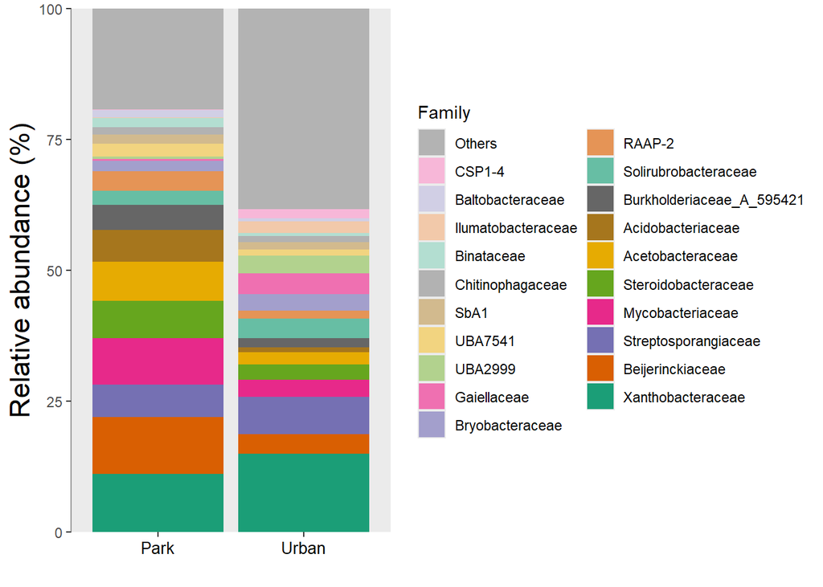

```r
p1
```

## Soil Fungi

```r
# Soil
dat <- clone(dsFSoil)
dat$tidy_dataset()
dat <- dat$merge_samples("Soil_type")

t1 <- trans_abund$new(dataset = dat, taxrank = "Family", ntaxa = 20)
```

```
## No taxa_abund list found. Calculate relative abundance with cal_abund function ...
```

```
## The result is stored in object$taxa_abund ...
```

```
## The transformed abundance data is stored in object$data_abund ...
```

```r
t1$data_abund
```

| Taxonomy | Sample | Abundance | SampleID | all_mean_abund |
| --- | --- | --- | --- | --- |
| Acarosporaceae | Urban | 0.000000e+00 | Urban | 3.256245e-04 |
| Acarosporaceae | Park | 6.512490e-02 | Park | 3.256245e-04 |
| Agaricaceae | Urban | 1.688423e-02 | Urban | 8.442116e-05 |
| Agaricaceae | Park | 0.000000e+00 | Park | 8.442116e-05 |
| Albatrellaceae | Urban | 0.000000e+00 | Urban | 1.109535e-04 |
| Albatrellaceae | Park | 2.219070e-02 | Park | 1.109535e-04 |
| Alphamycetaceae | Urban | 3.376846e-03 | Urban | 1.688423e-05 |
| Alphamycetaceae | Park | 0.000000e+00 | Park | 1.688423e-05 |
| Amanitaceae | Urban | 5.566973e-01 | Urban | 4.254826e-03 |
| Amanitaceae | Park | 2.942680e-01 | Park | 4.254826e-03 |

[output cut: 384 more lines]

```r
write.table(t1$data_abund, "Soil_fungi_comp_family.txt", sep = "\t")

p2 <- t1$plot_bar(
  others_color = "grey70",
  xtext_keep = TRUE,
  legend_text_italic = FALSE
)
```

```
## Input colors are not enough to use. Add more colors automatically via color interpolation ...
```

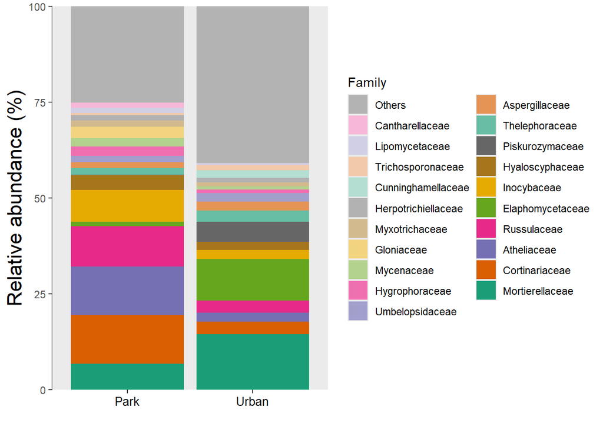

```r
p2
```

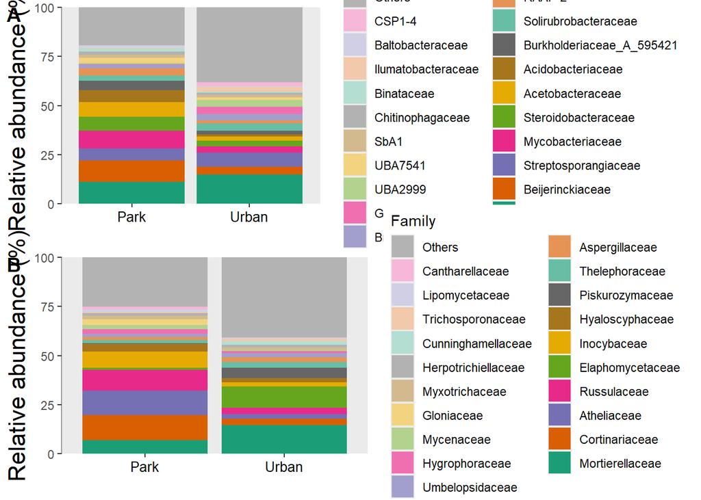

```r
plot_grid(p1,p2, ncol=1, labels = "AUTO")
```

```r
ggsave("Fig_bars_soils.png", width=7, height = 7, units = "in")
```

Fecal bacteria

```r
# Bacteria by Sampling timepoint
# Step 1: Prepare dataset
dat <- clone(dsBFec)
dat$tidy_dataset()
dat <- dat$merge_samples("Sampling_timepoint")

# Step 2: Build trans_abund object
t1 <- trans_abund$new(dataset = dat, taxrank = "Family", ntaxa = 20)
```

```
## No taxa_abund list found. Calculate relative abundance with cal_abund function ...
```

```
## The result is stored in object$taxa_abund ...
```

```
## The transformed abundance data is stored in object$data_abund ...
```

```r
# Write output table
write.table(t1$data_abund, "Fec_bacteria_comp_family.txt", sep = "\t")

# Step 3: Fix SampleID order inside the plotting data
t1$data_abund$SampleID <- factor(t1$data_abund$SampleID, levels = c("Pre", "Post"))

# Step 4: Plot
p1 <- t1$plot_bar(
  others_color = "grey70",
  xtext_keep = TRUE,
  legend_text_italic = FALSE
)
```

```
## Input colors are not enough to use. Add more colors automatically via color interpolation ...
```

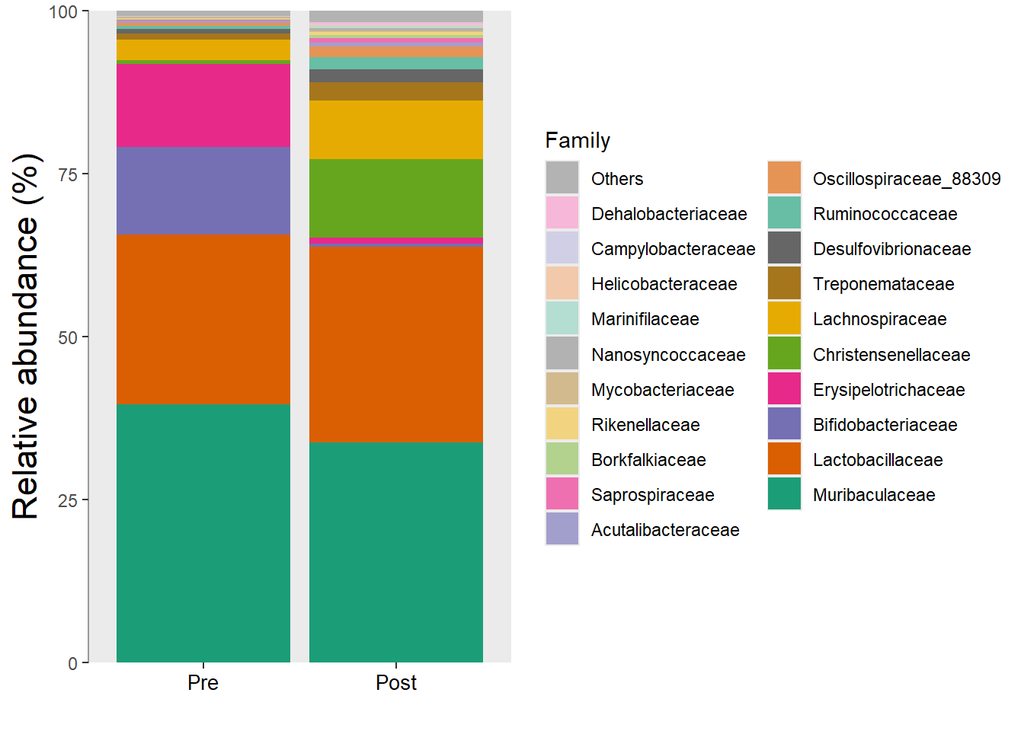

```r
# Force x-axis order manually
p1 <- p1 +
  ggplot2::scale_x_discrete(limits = c("Pre", "Post"))

print(p1)
```

## Faecal Bacteria

```r
# Bacteria at T2
dat <- clone(dsBFecT2)
dat$tidy_dataset()
dat <- dat$merge_samples("Soil_type")

t1 <- trans_abund$new(dataset = dat, taxrank = "Family", ntaxa = 20)
```

```
## No taxa_abund list found. Calculate relative abundance with cal_abund function ...
```

```
## The result is stored in object$taxa_abund ...
```

```
## The transformed abundance data is stored in object$data_abund ...
```

```r
p2 <- t1$plot_bar(others_color = "grey70", xtext_keep = TRUE, legend_text_italic = FALSE)
```

```
## Input colors are not enough to use. Add more colors automatically via color interpolation ...
```

```r
# Step 1: Prepare dataset
dat <- clone(dsFFec)
dat$tidy_dataset()
dat <- dat$merge_samples("Sampling_timepoint")

# Step 2: Build trans_abund object
t1 <- trans_abund$new(dataset = dat, taxrank = "Family", ntaxa = 20)
```

```
## No taxa_abund list found. Calculate relative abundance with cal_abund function ...
```

```
## The result is stored in object$taxa_abund ...
```

```
## The transformed abundance data is stored in object$data_abund ...
```

```r
# Write output table
write.table(t1$data_abund, "Fec_fungi_97clust_comp_family.txt", sep = "\t")

# Step 3: Fix SampleID order inside the plotting data
t1$data_abund$SampleID <- factor(t1$data_abund$SampleID, levels = c("Pre", "Post"))

# Step 4: Plot
p3 <- t1$plot_bar(
  others_color = "grey70",
  xtext_keep = TRUE,
  legend_text_italic = FALSE
)
```

```
## Input colors are not enough to use. Add more colors automatically via color interpolation ...
```

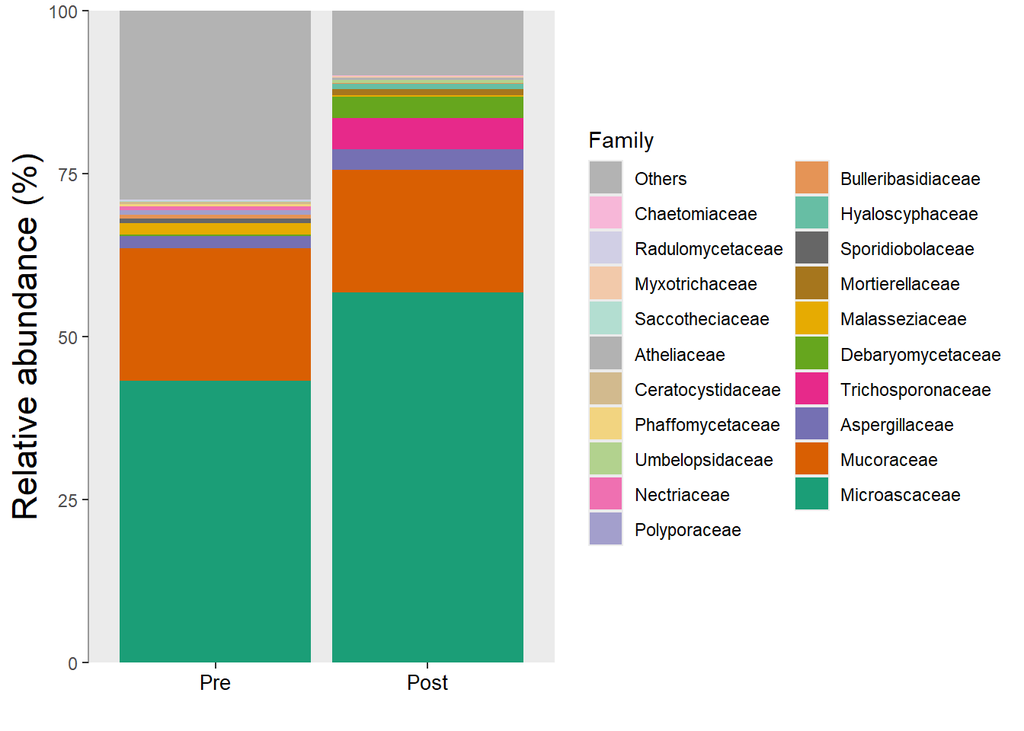

```r
# Force x-axis order manually
p3 <- p3 +
  ggplot2::scale_x_discrete(limits = c("Pre", "Post"))

print(p3)
```

## Faecal Fungi

```r
# Fungi at T2
dat <- clone(dsFFecT2)
dat$tidy_dataset()
dat <- dat$merge_samples("Soil_type")

t1 <- trans_abund$new(dataset = dat, taxrank = "Family", ntaxa = 20)
```

```
## No taxa_abund list found. Calculate relative abundance with cal_abund function ...
```

```
## The result is stored in object$taxa_abund ...
```

```
## The transformed abundance data is stored in object$data_abund ...
```

```r
p4 <- t1$plot_bar(others_color = "grey70", xtext_keep = TRUE, legend_text_italic = FALSE)
```

```
## Input colors are not enough to use. Add more colors automatically via color interpolation ...
```

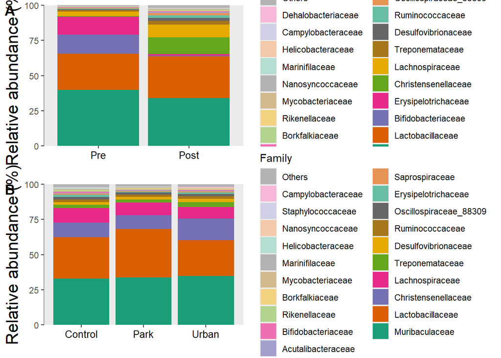

```r
plot_grid(p1,p2, ncol=1, labels = "AUTO")
```

```r
ggsave("Fig_bars_16S.png", width=7, height = 7, units = "in")
```

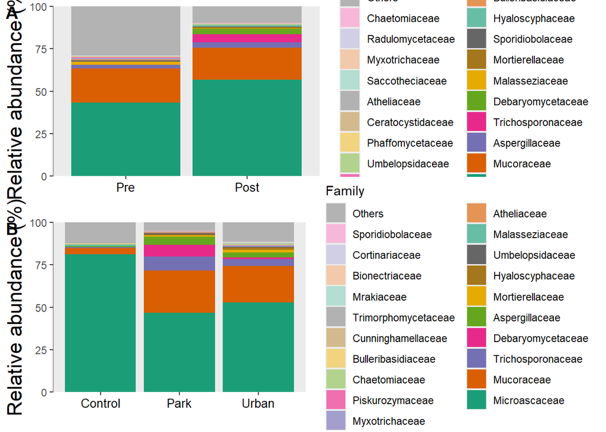

```r
plot_grid(p3,p4, ncol=1, labels = "AUTO")
```

```r
ggsave("Fig_bars_ITS2_97clust_.png", width=7, height = 7, units = "in")
```

# Core metrics

Calculate alpha and beta metrics. Ignore phylogenetic metrics for ITS2 data as the locus is unsuitable.

```r
dsFSoil$cal_alphadiv(PD = FALSE)
```

```
## The result is stored in object$alpha_diversity ...
```

```r
dsFSoil$cal_betadiv(unifrac = FALSE)
```

```
## The result is stored in object$beta_diversity ...
```

```r
dsFFec$cal_alphadiv(PD = FALSE)
```

```
## Skip the index Fisher because of an error ...
## The result is stored in object$alpha_diversity ...
```

```r
dsFFec$cal_betadiv(unifrac = FALSE)
```

```
## The result is stored in object$beta_diversity ...
```

```r
dsBSoil$cal_alphadiv(PD = TRUE)
```

```
## The result is stored in object$alpha_diversity ...
```

```r
dsBSoil$cal_betadiv(unifrac = TRUE)
```

```
## Accumulate the abundance along the tree branches...
## Compute pairwise distances ...
## Completed!
```

```
## The result is stored in object$beta_diversity ...
```

```r
dsBFec$cal_alphadiv(PD = TRUE)
```

```
## The result is stored in object$alpha_diversity ...
```

```r
dsBFec$cal_betadiv(unifrac = TRUE)
```

```
## Accumulate the abundance along the tree branches...
## Compute pairwise distances ...
## Completed!
```

```
## The result is stored in object$beta_diversity ...
```

Create metadata frames to use for alpha and beta plots and models

```r
dat1 <- dsFSoil$sample_table %>% rownames_to_column("SampleID")
dat2 <- dsFSoil$alpha_diversity %>% rownames_to_column("SampleID")
dfFS <- left_join(dat1, dat2, by = "SampleID")

dat1 <- dsFFec$sample_table %>% rownames_to_column("SampleID")
dat2 <- dsFFec$alpha_diversity %>% rownames_to_column("SampleID")
dfFF <- left_join(dat1, dat2, by = "SampleID")


dat1 <- dsBSoil$sample_table %>% rownames_to_column("SampleID")
dat2 <- dsBSoil$alpha_diversity %>% rownames_to_column("SampleID")
dfBS <- left_join(dat1, dat2, by = "SampleID")

dat1 <- dsBFec$sample_table %>% rownames_to_column("SampleID")
dat2 <- dsBFec$alpha_diversity %>% rownames_to_column("SampleID")
dfBF <- left_join(dat1, dat2, by = "SampleID")
```

# Alpha diversity plots

## Soil

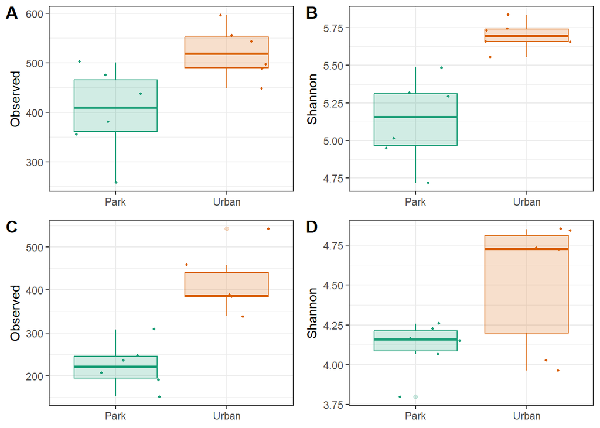

```r
# Draw plots
p1 <- ggplot(dfBS, aes(x = Soil_type, y = Observed, color = Soil_type)) +
  geom_boxplot(aes(fill=Soil_type), alpha=0.2) +
  geom_jitter(size=0.8) +
  theme_bw() +
  scale_color_brewer(type = "qual", palette = "Dark2") +
  scale_fill_brewer(type = "qual", palette = "Dark2") +
  labs(color="Soil type", fill = "Soil type") +
  theme(axis.title.x=element_blank(),
        legend.position = "none"
        )


p2 <- ggplot(dfBS, aes(x = Soil_type, y = Shannon, color = Soil_type)) +
  geom_boxplot(aes(fill=Soil_type), alpha=0.2) +
  geom_jitter(size=0.8) +
  theme_bw() +
  scale_color_brewer(type = "qual", palette = "Dark2") +
  scale_fill_brewer(type = "qual", palette = "Dark2") +
  labs(color="Soil type", fill = "Soil type") +
  theme(axis.title.x=element_blank(),
        legend.position = "none"
        )

p3 <- ggplot(dfFS, aes(x = Soil_type, y = Observed, color = Soil_type)) +
  geom_boxplot(aes(fill=Soil_type), alpha=0.2) +
  geom_jitter(size=0.8) +
  theme_bw() +
  scale_color_brewer(type = "qual", palette = "Dark2") +
  scale_fill_brewer(type = "qual", palette = "Dark2") +
  labs(color="Soil type", fill = "Soil type") +
  theme(axis.title.x=element_blank(),
        legend.position = "none"
        )


p4 <- ggplot(dfFS, aes(x = Soil_type, y = Shannon, color = Soil_type)) +
  geom_boxplot(aes(fill=Soil_type), alpha=0.2) +
  geom_jitter(size=0.8) +
  theme_bw() +
  scale_color_brewer(type = "qual", palette = "Dark2") +
  scale_fill_brewer(type = "qual", palette = "Dark2") +
  labs(color="Soil type", fill = "Soil type") +
  theme(axis.title.x=element_blank(),
        legend.position = "none"
        )

plot_grid(p1,p2,p3,p4, align = "hv", axis="l", ncol = 2, labels="AUTO")
```

```r
ggsave("Fig_alpha_soil_ITS97clust_16S.png", width=5, height = 5, units = "in")
```

## Faeces

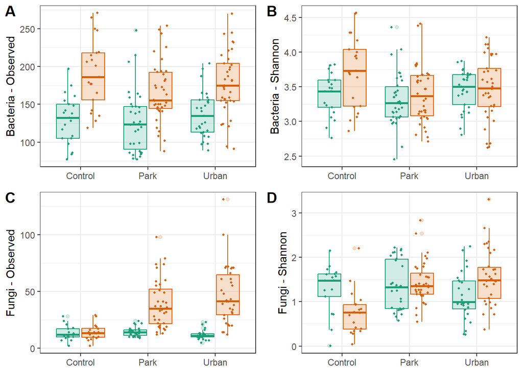

```r
# Draw plots

p1 <- ggplot(dfFF, aes(x = Soil_type, y = Observed, color = Sampling_timepoint)) +
  geom_boxplot(aes(fill=Sampling_timepoint), alpha=0.2) +
  geom_jitter(position = position_jitterdodge(), size=0.8) +
  theme_bw() +
  scale_color_brewer(type = "qual", palette = "Dark2") +
  scale_fill_brewer(type = "qual", palette = "Dark2") +
  labs(color="Sampling\ntimepoint",
       fill = "Sampling\ntimepoint",
       y = "Fungi - Observed") +
  theme(axis.title.x=element_blank(),
        legend.position = "none"
        )

p2 <- ggplot(dfFF, aes(x = Soil_type, y = Shannon, color = Sampling_timepoint)) +
  geom_boxplot(aes(fill=Sampling_timepoint), alpha=0.2) +
  geom_jitter(position = position_jitterdodge(), size=0.8) +
  theme_bw() +
  scale_color_brewer(type = "qual", palette = "Dark2") +
  scale_fill_brewer(type = "qual", palette = "Dark2") +
  labs(color="Sampling\ntimepoint", fill = "Sampling\ntimepoint",
       y = "Fungi - Shannon") +
  theme(axis.title.x=element_blank(),
        legend.position = "none"
        )

p3 <- ggplot(dfBF, aes(x = Soil_type, y = Observed, color = Sampling_timepoint)) +
  geom_boxplot(aes(fill=Sampling_timepoint), alpha=0.2) +
  geom_jitter(position = position_jitterdodge(), size=0.8) +
  theme_bw() +
  scale_color_brewer(type = "qual", palette = "Dark2") +
  scale_fill_brewer(type = "qual", palette = "Dark2") +
  labs(color="Sampling\ntimepoint",
       fill = "Sampling\ntimepoint",
       y = "Bacteria - Observed") +
  theme(axis.title.x=element_blank(),
        legend.position = "none"
        )

p4 <- ggplot(dfBF, aes(x = Soil_type, y = Shannon, color = Sampling_timepoint)) +
  geom_boxplot(aes(fill=Sampling_timepoint), alpha=0.2) +
  geom_jitter(position = position_jitterdodge(), size=0.8) +
  theme_bw() +
  scale_color_brewer(type = "qual", palette = "Dark2") +
  scale_fill_brewer(type = "qual", palette = "Dark2") +
  labs(color="Sampling\ntimepoint",
       fill = "Sampling\ntimepoint",
       y = "Bacteria - Shannon") +
  theme(axis.title.x=element_blank(),
        legend.position = "none"
        )

p5 <- ggplot(dfBF, aes(x = Soil_type, y = PD, color = Sampling_timepoint)) +
  geom_boxplot(aes(fill=Sampling_timepoint), alpha=0.2) +
  geom_jitter(position = position_jitterdodge(), size=0.8) +
  theme_bw() +
  scale_color_brewer(type = "qual", palette = "Dark2") +
  scale_fill_brewer(type = "qual", palette = "Dark2") +
  labs(color="Sampling\ntimepoint",
       fill = "Sampling\ntimepoint",
       y = "Bacteria - PD") +
  theme(axis.title.x=element_blank(),
        legend.position = "none"
        )



plot_grid(p3,p4,p1,p2, align = "hv", axis="l", labels = c("A", "B", "C","D"))
```

```r
ggsave("Fig_alpha_fec_97clust_16S_NoPD.png", width=9, height = 6, units = "in")
```

# Alpha diversity models

## Soil

Alpha stats

```r
dfFS %>% # fungi
  group_by(Soil_location) %>%
  summarise_at(vars(Observed), list(name = mean)) %>%
  print() %>%
  write.table("alphares/soil.alpha.ITS2.txt", sep="\t")
```

```
## # A tibble: 6 × 2
##   Soil_location  name
##   <chr>         <dbl>
## 1 2_Kvesi        278.
## 2 2_Lmaki        180
## 3 2_Phakki       213
## 4 3_JKL          500
## 5 3_Kuopio       385
## 6 3_Mikkeli      364.
```

```r
dfFS %>%
  group_by(Soil_type) %>%
  summarise_at(vars(Observed), list(name = mean)) %>%
  print()
```

```
## # A tibble: 2 × 2
##   Soil_type  name
##   <chr>     <dbl>
## 1 Park       224.
## 2 Urban      416.
```

```r
dfBS %>%
  group_by(Soil_location) %>%
  summarise_at(vars(Observed), list(name = mean)) %>%
  print() %>%
  write.table("alphares/soil.alpha.16S.txt", sep="\t")
```

```
## # A tibble: 6 × 2
##   Soil_location  name
##   <chr>         <dbl>
## 1 2_Kvesi        488.
## 2 2_Lmaki        368.
## 3 2_Phakki       348
## 4 3_JKL          494.
## 5 3_Kuopio       526.
## 6 3_Mikkeli      542.
```

```r
dfBS %>%
  group_by(Soil_type) %>%
  summarise_at(vars(Observed), list(name = mean)) %>%
  print()
```

```
## # A tibble: 2 × 2
##   Soil_type  name
##   <chr>     <dbl>
## 1 Park       401
## 2 Urban      521.
```

Alpha models

```r
# Alpha models for soil
M1 <- t.test(Observed ~ Soil_type, data = dfBS)
M2 <- t.test(Shannon ~ Soil_type, data = dfBS)

M3 <- t.test(Observed ~ Soil_type, data = dfFS)
M4 <- t.test(Shannon ~ Soil_type, data = dfFS)

M1
```

```
##
##  Welch Two Sample t-test
##
## data:  Observed by Soil_type
## t = -2.813, df = 8.1786, p-value = 0.02225
## alternative hypothesis: true difference in means between group Park and group Urban is not equal to 0
## 95 percent confidence interval:
##  -217.69513  -21.97154
## sample estimates:
##  mean in group Park mean in group Urban
##            401.0000            520.8333
```

```r
M2
```

```
##
##  Welch Two Sample t-test
##
## data:  Shannon by Soil_type
## t = -4.637, df = 6.1405, p-value = 0.003345
## alternative hypothesis: true difference in means between group Park and group Urban is not equal to 0
## 95 percent confidence interval:
##  -0.8667132 -0.2701250
## sample estimates:
##  mean in group Park mean in group Urban
##            5.129649            5.698068
```

```r
M3
```

```
##
##  Welch Two Sample t-test
##
## data:  Observed by Soil_type
## t = -5.2221, df = 9.2179, p-value = 0.0005068
## alternative hypothesis: true difference in means between group Park and group Urban is not equal to 0
## 95 percent confidence interval:
##  -275.3516 -109.3151
## sample estimates:
##  mean in group Park mean in group Urban
##            223.8333            416.1667
```

```r
M4
```

```
##
##  Welch Two Sample t-test
##
## data:  Shannon by Soil_type
## t = -2.2569, df = 6.5935, p-value = 0.06089
## alternative hypothesis: true difference in means between group Park and group Urban is not equal to 0
## 95 percent confidence interval:
##  -0.8461730  0.0250347
## sample estimates:
##  mean in group Park mean in group Urban
##            4.111023            4.521592
```

## Faecal fungi

Observed

```r
# Fit full model and reduced model without sex
m1 <- lmer(Observed ~ Soil_type * Sampling_timepoint +  (1|Mother_ID) + (1|Pup_ID) , data = dfFF, REML = FALSE)
```

```
## boundary (singular) fit: see help('isSingular')
```

```r
m0 <- lmer(Observed ~ Soil_type * Sampling_timepoint + sex + (1|Mother_ID) + (1|Pup_ID) , data = dfFF, REML = FALSE)
```

```
## boundary (singular) fit: see help('isSingular')
```

```r
# LRT
anova(m1, m0) # p > 0.05 -> sex can be ignored
```

|  | npar | AIC | BIC | logLik | deviance | Chisq | Df | Pr(>Chisq) |
| --- | --- | --- | --- | --- | --- | --- | --- | --- |
| m1 | 9 | 1379.991 | 1407.835 | -680.9954 | 1361.991 | NA | NA | NA |
| m0 | 10 | 1381.717 | 1412.655 | -680.8587 | 1361.717 | 0.2735174 | 1 | 0.600982 |

```r
# Fit model
m1 <- lmer(Observed ~ Soil_type * Sampling_timepoint +  (1|Mother_ID) + (1|Pup_ID)  , data = dfFF, REML = TRUE)
```

```
## boundary (singular) fit: see help('isSingular')
```

```r
# Get model summary and R2
summary(m1)
```

```
## Linear mixed model fit by REML. t-tests use Satterthwaite's method [
## lmerModLmerTest]
## Formula: Observed ~ Soil_type * Sampling_timepoint + (1 | Mother_ID) +
##     (1 | Pup_ID)
##    Data: dfFF
##
## REML criterion at convergence: 1337.2
##
## Scaled residuals:
##     Min      1Q  Median      3Q     Max
## -2.0564 -0.3594 -0.0735  0.3235  4.8947
##
## Random effects:
##  Groups    Name        Variance Std.Dev.
##  Pup_ID    (Intercept)   0.00    0.000
##  Mother_ID (Intercept)  21.06    4.589
##  Residual              240.20   15.498
## Number of obs: 163, groups:  Pup_ID, 98; Mother_ID, 47
##
## Fixed effects:
##                                       Estimate Std. Error       df t value
## (Intercept)                            13.3510     3.9552 152.0492   3.376
## Soil_typePark                           0.5911     4.8379 151.6569   0.122
## Soil_typeUrban                         -2.1121     5.0171 156.6234  -0.421
## Sampling_timepointPost                  0.0878     5.1495 128.3690   0.017
## Soil_typePark:Sampling_timepointPost   24.9605     6.4412 129.5790   3.875
## Soil_typeUrban:Sampling_timepointPost  35.8102     6.5613 128.2470   5.458
##                                       Pr(>|t|)
## (Intercept)                           0.000935 ***
## Soil_typePark                         0.902916
## Soil_typeUrban                        0.674348
## Sampling_timepointPost                0.986424
## Soil_typePark:Sampling_timepointPost  0.000168 ***
## Soil_typeUrban:Sampling_timepointPost  2.4e-07 ***
## ---
## Signif. codes:  0 '***' 0.001 '**' 0.01 '*' 0.05 '.' 0.1 ' ' 1
##
## Correlation of Fixed Effects:
##             (Intr) Sl_tyP Sl_tyU Smpl_P S_P:S_
## Soil_typPrk -0.790
## Sol_typUrbn -0.771  0.628
## Smplng_tmpP -0.711  0.582  0.560
## Sl_typP:S_P  0.569 -0.726 -0.451 -0.801
## Sl_typU:S_P  0.559 -0.459 -0.728 -0.784  0.629
## optimizer (nloptwrap) convergence code: 0 (OK)
## boundary (singular) fit: see help('isSingular')
```

```r
r2 <- round(r.squaredGLMM(m1),digits=3)
r2
```

```
##        R2m  R2c
## [1,] 0.468 0.51
```

```r
# export model summary
write.table(
  x = as_tibble(round(coef(
    summary(m1)), digits = 4), rownames = NA) %>%
    tibble::rownames_to_column(., "Predictor"),
  file = "alphares/LMM_fecal_ITS2_obs.txt",
  sep = "\t",
  row.names = FALSE)

# Export R2
r2 <- t(r2)
write.table(r2, file = "alphares/LMM_fecal_ITS2_obs_R2.txt", sep = "\t")
```

Shannon

```r
# Fit full model and reduced morel without sex
m1 <- lmer(Shannon ~ Soil_type * Sampling_timepoint +  (1|Mother_ID) + (1|Pup_ID) , data = dfFF, REML = FALSE)
```

```
## boundary (singular) fit: see help('isSingular')
```

```r
m0 <- lmer(Shannon ~ Soil_type * Sampling_timepoint + sex + (1|Mother_ID) + (1|Pup_ID) , data = dfFF, REML = FALSE)
```

```
## boundary (singular) fit: see help('isSingular')
```

```r
# LRT
anova(m1, m0) # p > 0.05 -> sex can be ignored
```

|  | npar | AIC | BIC | logLik | deviance | Chisq | Df | Pr(>Chisq) |
| --- | --- | --- | --- | --- | --- | --- | --- | --- |
| m1 | 9 | 256.4878 | 284.3316 | -119.2439 | 238.4878 | NA | NA | NA |
| m0 | 10 | 257.0232 | 287.9607 | -118.5116 | 237.0232 | 1.46465 | 1 | 0.2261917 |

```r
# Fit model
m1 <- lmer(Shannon ~ Soil_type * Sampling_timepoint +  (1|Mother_ID) + (1|Pup_ID)  , data = dfFF, REML = TRUE)
```

```
## boundary (singular) fit: see help('isSingular')
```

```r
# Get model summary and R2
summary(m1)
```

```
## Linear mixed model fit by REML. t-tests use Satterthwaite's method [
## lmerModLmerTest]
## Formula: Shannon ~ Soil_type * Sampling_timepoint + (1 | Mother_ID) +
##     (1 | Pup_ID)
##    Data: dfFF
##
## REML criterion at convergence: 255
##
## Scaled residuals:
##      Min       1Q   Median       3Q      Max
## -2.30071 -0.62393 -0.05239  0.53471  2.81480
##
## Random effects:
##  Groups    Name        Variance Std.Dev.
##  Pup_ID    (Intercept) 0.00000  0.0000
##  Mother_ID (Intercept) 0.09186  0.3031
##  Residual              0.20387  0.4515
## Number of obs: 163, groups:  Pup_ID, 98; Mother_ID, 47
##
## Fixed effects:
##                                         Estimate Std. Error         df t value
## (Intercept)                             1.329304   0.128526 154.924455  10.343
## Soil_typePark                          -0.001698   0.147643 138.115604  -0.011
## Soil_typeUrban                         -0.192078   0.155927 146.578467  -1.232
## Sampling_timepointPost                 -0.606280   0.152248 123.692672  -3.982
## Soil_typePark:Sampling_timepointPost    0.712453   0.190669 124.224305   3.737
## Soil_typeUrban:Sampling_timepointPost   1.021334   0.193962 123.676471   5.266
##                                       Pr(>|t|)
## (Intercept)                            < 2e-16 ***
## Soil_typePark                         0.990842
## Soil_typeUrban                        0.219979
## Sampling_timepointPost                0.000116 ***
## Soil_typePark:Sampling_timepointPost  0.000283 ***
## Soil_typeUrban:Sampling_timepointPost 5.98e-07 ***
## ---
## Signif. codes:  0 '***' 0.001 '**' 0.01 '*' 0.05 '.' 0.1 ' ' 1
##
## Correlation of Fixed Effects:
##             (Intr) Sl_tyP Sl_tyU Smpl_P S_P:S_
## Soil_typPrk -0.755
## Sol_typUrbn -0.739  0.637
## Smplng_tmpP -0.657  0.571  0.539
## Sl_typP:S_P  0.525 -0.708 -0.439 -0.803
## Sl_typU:S_P  0.517 -0.453 -0.703 -0.783  0.630
## optimizer (nloptwrap) convergence code: 0 (OK)
## boundary (singular) fit: see help('isSingular')
```

```r
r2 <- round(r.squaredGLMM(m1),digits=3)
r2
```

```
##        R2m   R2c
## [1,] 0.175 0.431
```

```r
# export model summary
write.table(
  x = as_tibble(round(coef(
    summary(m1)), digits = 4), rownames = NA) %>%
    tibble::rownames_to_column(., "Predictor"),
  file = "alphares/LMM_fecal_fungi_97clust_shannon.txt",
  sep = "\t",
  row.names = FALSE
  )

# Export R2
r2 <- t(r2)
write.table(r2, file = "alphares/LMM_fecal_fungi_97clust_shannon_R2.txt", sep = "\t")
```

## Faecal bacteria

Observed

```r
# Fit full model and reduced model without sex
m1 <- lmer(Observed ~ Soil_type * Sampling_timepoint +  (1|Mother_ID) + (1|Pup_ID) , data = dfBF, REML = FALSE)
```

```
## boundary (singular) fit: see help('isSingular')
```

```r
m0 <- lmer(Observed ~ Soil_type * Sampling_timepoint + sex + (1|Mother_ID) + (1|Pup_ID) , data = dfBF, REML = FALSE)
```

```
## boundary (singular) fit: see help('isSingular')
```

```r
# LRT
anova(m1, m0) # p > 0.05 -> sex can be ignored
```

|  | npar | AIC | BIC | logLik | deviance | Chisq | Df | Pr(>Chisq) |
| --- | --- | --- | --- | --- | --- | --- | --- | --- |
| m1 | 9 | 1840.218 | 1868.955 | -911.1092 | 1822.218 | NA | NA | NA |
| m0 | 10 | 1841.107 | 1873.037 | -910.5537 | 1821.107 | 1.111019 | 1 | 0.2918605 |

```r
# Fit model
m1 <- lmer(Observed ~ Soil_type * Sampling_timepoint +  (1|Mother_ID) + (1|Pup_ID)  , data = dfBF, REML = TRUE)
```

```
## boundary (singular) fit: see help('isSingular')
```

```r
# Get model summary and R2
summary(m1)
```

```
## Linear mixed model fit by REML. t-tests use Satterthwaite's method [
## lmerModLmerTest]
## Formula: Observed ~ Soil_type * Sampling_timepoint + (1 | Mother_ID) +
##     (1 | Pup_ID)
##    Data: dfBF
##
## REML criterion at convergence: 1787.5
##
## Scaled residuals:
##     Min      1Q  Median      3Q     Max
## -2.1825 -0.6067 -0.1072  0.5379  2.9756
##
## Random effects:
##  Groups    Name        Variance Std.Dev.
##  Pup_ID    (Intercept)    0.0    0.00
##  Mother_ID (Intercept)  125.4   11.20
##  Residual              1400.2   37.42
## Number of obs: 180, groups:  Pup_ID, 99; Mother_ID, 48
##
## Fixed effects:
##                                       Estimate Std. Error      df t value
## (Intercept)                            130.410      8.584 168.698  15.192
## Soil_typePark                           -2.458     10.692 169.253  -0.230
## Soil_typeUrban                           6.138     11.129 173.634   0.552
## Sampling_timepointPost                  60.818     11.589 136.412   5.248
## Soil_typePark:Sampling_timepointPost   -22.298     14.589 136.085  -1.528
## Soil_typeUrban:Sampling_timepointPost  -20.126     14.888 138.639  -1.352
##                                       Pr(>|t|)
## (Intercept)                            < 2e-16 ***
## Soil_typePark                            0.818
## Soil_typeUrban                           0.582
## Sampling_timepointPost                5.75e-07 ***
## Soil_typePark:Sampling_timepointPost     0.129
## Soil_typeUrban:Sampling_timepointPost    0.179
## ---
## Signif. codes:  0 '***' 0.001 '**' 0.01 '*' 0.05 '.' 0.1 ' ' 1
##
## Correlation of Fixed Effects:
##             (Intr) Sl_tyP Sl_tyU Smpl_P S_P:S_
## Soil_typPrk -0.774
## Sol_typUrbn -0.753  0.599
## Smplng_tmpP -0.675  0.544  0.521
## Sl_typP:S_P  0.535 -0.698 -0.413 -0.795
## Sl_typU:S_P  0.528 -0.426 -0.704 -0.780  0.620
## optimizer (nloptwrap) convergence code: 0 (OK)
## boundary (singular) fit: see help('isSingular')
```

```r
r2 <- round(r.squaredGLMM(m1),digits=3)
r2
```

```
##        R2m   R2c
## [1,] 0.265 0.325
```

```r
# export model summary
write.table(
  x = as_tibble(round(coef(
    summary(m1)), digits = 4), rownames = NA) %>%
    tibble::rownames_to_column(., "Predictor"),
  file = "alphares/LMM_fecal_16S_obs.txt",
  sep = "\t",
  row.names = FALSE)

# Export R2
r2 <- t(r2)
write.table(r2, file = "alphares/LMM_fecal_16S_obs_R2.txt", sep = "\t")
```

Shannon

```r
# Fit full model and reduced morel without sex
m1 <- lmer(Shannon ~ Soil_type * Sampling_timepoint +  (1|Mother_ID) + (1|Pup_ID) , data = dfBF, REML = FALSE)
m0 <- lmer(Shannon ~ Soil_type * Sampling_timepoint + sex + (1|Mother_ID) + (1|Pup_ID) , data = dfBF, REML = FALSE)
```

```
## boundary (singular) fit: see help('isSingular')
```

```r
# LRT
anova(m1, m0) # p > 0.05 -> sex can be ignored
```

|  | npar | AIC | BIC | logLik | deviance | Chisq | Df | Pr(>Chisq) |
| --- | --- | --- | --- | --- | --- | --- | --- | --- |
| m1 | 9 | 187.3213 | 216.0579 | -84.66067 | 169.3213 | NA | NA | NA |
| m0 | 10 | 189.2956 | 221.2252 | -84.64779 | 169.2956 | 0.02574989 | 1 | 0.8725127 |

```r
# Fit model
m1 <- lmer(Shannon ~ Soil_type * Sampling_timepoint +  (1|Mother_ID) + (1|Pup_ID)  , data = dfBF, REML = TRUE)
```

```
## boundary (singular) fit: see help('isSingular')
```

```r
# Get model summary and R2
summary(m1)
```

```
## Linear mixed model fit by REML. t-tests use Satterthwaite's method [
## lmerModLmerTest]
## Formula: Shannon ~ Soil_type * Sampling_timepoint + (1 | Mother_ID) +
##     (1 | Pup_ID)
##    Data: dfBF
##
## REML criterion at convergence: 189.7
##
## Scaled residuals:
##      Min       1Q   Median       3Q      Max
## -2.34187 -0.66096  0.00616  0.63069  2.42466
##
## Random effects:
##  Groups    Name        Variance  Std.Dev.
##  Pup_ID    (Intercept) 2.329e-11 4.826e-06
##  Mother_ID (Intercept) 1.422e-02 1.192e-01
##  Residual              1.429e-01 3.781e-01
## Number of obs: 180, groups:  Pup_ID, 99; Mother_ID, 48
##
## Fixed effects:
##                                        Estimate Std. Error        df t value
## (Intercept)                             3.38392    0.08712 169.67158  38.842
## Soil_typePark                          -0.07031    0.10829 169.67069  -0.649
## Soil_typeUrban                          0.07191    0.11280 173.57266   0.637
## Sampling_timepointPost                  0.34130    0.11713 141.35035   2.914
## Soil_typePark:Sampling_timepointPost   -0.27208    0.14745 141.04342  -1.845
## Soil_typeUrban:Sampling_timepointPost  -0.32819    0.15049 143.31800  -2.181
##                                       Pr(>|t|)
## (Intercept)                            < 2e-16 ***
## Soil_typePark                          0.51701
## Soil_typeUrban                         0.52464
## Sampling_timepointPost                 0.00415 **
## Soil_typePark:Sampling_timepointPost   0.06710 .
## Soil_typeUrban:Sampling_timepointPost  0.03083 *
## ---
## Signif. codes:  0 '***' 0.001 '**' 0.01 '*' 0.05 '.' 0.1 ' ' 1
##
## Correlation of Fixed Effects:
##             (Intr) Sl_tyP Sl_tyU Smpl_P S_P:S_
## Soil_typPrk -0.773
## Sol_typUrbn -0.752  0.599
## Smplng_tmpP -0.672  0.543  0.519
## Sl_typP:S_P  0.533 -0.697 -0.412 -0.795
## Sl_typU:S_P  0.527 -0.426 -0.702 -0.780  0.620
## optimizer (nloptwrap) convergence code: 0 (OK)
## boundary (singular) fit: see help('isSingular')
```

```r
r2 <- round(r.squaredGLMM(m1),digits=3)
r2
```

```
##        R2m   R2c
## [1,] 0.081 0.164
```

```r
# export model summary
write.table(
  x = as_tibble(round(coef(
    summary(m1)), digits = 4), rownames = NA) %>%
    tibble::rownames_to_column(., "Predictor"),
  file = "alphares/LMM_fecal_16S_shannon.txt",
  sep = "\t",
  row.names = FALSE
  )

# Export R2
r2 <- t(r2)
write.table(r2, file = "alphares/LMM_fecal_16S_shannon_R2.txt", sep = "\t")
```

PD

```r
# Fit full model and reduced morel without sex
m1 <- lmer(PD ~ Soil_type * Sampling_timepoint +  (1|Mother_ID) + (1|Pup_ID) , data = dfBF, REML = FALSE)
```

```
## boundary (singular) fit: see help('isSingular')
```

```r
m0 <- lmer(PD ~ Soil_type * Sampling_timepoint + sex + (1|Mother_ID) + (1|Pup_ID) , data = dfBF, REML = FALSE)
```

```
## boundary (singular) fit: see help('isSingular')
```

```r
# LRT
anova(m1, m0) # p > 0.05 -> sex can be ignored
```

|  | npar | AIC | BIC | logLik | deviance | Chisq | Df | Pr(>Chisq) |
| --- | --- | --- | --- | --- | --- | --- | --- | --- |
| m1 | 9 | 862.692 | 891.4286 | -422.3460 | 844.692 | NA | NA | NA |
| m0 | 10 | 862.215 | 894.1446 | -421.1075 | 842.215 | 2.476929 | 1 | 0.1155276 |

```r
# Fit model
m1 <- lmer(PD ~ Soil_type * Sampling_timepoint +  (1|Mother_ID) + (1|Pup_ID)  , data = dfBF, REML = TRUE)
```

```
## boundary (singular) fit: see help('isSingular')
```

```r
# Get model summary and R2
summary(m1)
```

```
## Linear mixed model fit by REML. t-tests use Satterthwaite's method [
## lmerModLmerTest]
## Formula: PD ~ Soil_type * Sampling_timepoint + (1 | Mother_ID) + (1 |
##     Pup_ID)
##    Data: dfBF
##
## REML criterion at convergence: 842.4
##
## Scaled residuals:
##      Min       1Q   Median       3Q      Max
## -2.05413 -0.64448  0.00059  0.62233  2.98486
##
## Random effects:
##  Groups    Name        Variance Std.Dev.
##  Pup_ID    (Intercept) 0.000    0.000
##  Mother_ID (Intercept) 1.252    1.119
##  Residual              5.668    2.381
## Number of obs: 180, groups:  Pup_ID, 99; Mother_ID, 48
##
## Fixed effects:
##                                       Estimate Std. Error       df t value
## (Intercept)                            13.1217     0.5744 169.4330  22.843
## Soil_typePark                          -0.2203     0.6977 164.2999  -0.316
## Soil_typeUrban                          0.5832     0.7318 170.8577   0.797
## Sampling_timepointPost                  4.3621     0.7400 135.6747   5.895
## Soil_typePark:Sampling_timepointPost   -0.8900     0.9313 135.2226  -0.956
## Soil_typeUrban:Sampling_timepointPost  -1.0125     0.9518 137.5030  -1.064
##                                       Pr(>|t|)
## (Intercept)                            < 2e-16 ***
## Soil_typePark                            0.753
## Soil_typeUrban                           0.427
## Sampling_timepointPost                2.82e-08 ***
## Soil_typePark:Sampling_timepointPost     0.341
## Soil_typeUrban:Sampling_timepointPost    0.289
## ---
## Signif. codes:  0 '***' 0.001 '**' 0.01 '*' 0.05 '.' 0.1 ' ' 1
##
## Correlation of Fixed Effects:
##             (Intr) Sl_tyP Sl_tyU Smpl_P S_P:S_
## Soil_typPrk -0.758
## Sol_typUrbn -0.739  0.599
## Smplng_tmpP -0.644  0.534  0.505
## Sl_typP:S_P  0.510 -0.684 -0.401 -0.795
## Sl_typU:S_P  0.507 -0.420 -0.687 -0.781  0.620
## optimizer (nloptwrap) convergence code: 0 (OK)
## boundary (singular) fit: see help('isSingular')
```

```r
r2 <- round(r.squaredGLMM(m1),digits=3)
r2
```

```
##        R2m   R2c
## [1,] 0.335 0.455
```

```r
# export model summary
write.table(
  x = as_tibble(round(coef(
    summary(m1)), digits = 4), rownames = NA) %>%
    tibble::rownames_to_column(., "Predictor"),
  file = "alphares/LMM_fecal_16S_PD.txt",
  sep = "\t",
  row.names = FALSE
  )

# Export R2
r2 <- t(r2)
write.table(r2, file = "alphares/LMM_fecal_16S_PD_R2.txt", sep = "\t")
```

# Beta diversity plots

## Time

```r
# Set data
dat1 <- dsBFec
dat2 <- dsFFec


# Get legend
t1 <- trans_beta$new(dataset = dat1, group = "Sampling_timepoint", measure = "bray")
t1$cal_ordination(method = "PCoA")
```

```
## The result is stored in object$res_ordination ...
```

```r
class(t1$res_ordination)
```

```
## [1] "list"
```

```r
p1 <- t1$plot_ordination(plot_color = "Sampling_timepoint", plot_shape = "Soil_type", plot_type = c("point")) +
  labs(color="Sampling\ntimepoint",
       shape = "Soil type") +
  theme_bw()
legend <- get_legend(p1)
# 16S
# Jaccard
t1 <- trans_beta$new(dataset = dat1, group = "Sampling_timepoint", measure = "jaccard")
t1$cal_ordination(method = "PCoA")
```

```
## The result is stored in object$res_ordination ...
```

```r
class(t1$res_ordination)
```

```
## [1] "list"
```

```r
p1 <- t1$plot_ordination(plot_color = "Sampling_timepoint", plot_shape = "Soil_type", plot_type = c("point")) +
  ggtitle("Bacteria - Jaccard") +
  theme_bw() +
  theme(legend.position = "none")

# Bray-Curtis
t1 <- trans_beta$new(dataset = dat1, group = "Sampling_timepoint", measure = "bray")
t1$cal_ordination(method = "PCoA")
```

```
## The result is stored in object$res_ordination ...
```

```r
class(t1$res_ordination)
```

```
## [1] "list"
```

```r
p2 <- t1$plot_ordination(plot_color = "Sampling_timepoint", plot_shape = "Soil_type", plot_type = c("point")) +
  ggtitle("Bacteria - Bray-Curtis") +
  theme_bw() +
  theme(legend.position = "none")


# ITS2
# Jaccard
t1 <- trans_beta$new(dataset = dat2, group = "Sampling_timepoint", measure = "jaccard")
t1$cal_ordination(method = "PCoA")
```

```
## The result is stored in object$res_ordination ...
```

```r
class(t1$res_ordination)
```

```
## [1] "list"
```

```r
p5 <- t1$plot_ordination(plot_color = "Sampling_timepoint", plot_shape = "Soil_type", plot_type = c("point")) +
  ggtitle("Fungi - Jaccard") +
  theme_bw() +
  theme(legend.position = "none")

# Bray-Curtis
t1 <- trans_beta$new(dataset = dat2, group = "Sampling_timepoint", measure = "bray")
t1$cal_ordination(method = "PCoA")
```

```
## The result is stored in object$res_ordination ...
```

```r
class(t1$res_ordination)
```

```
## [1] "list"
```

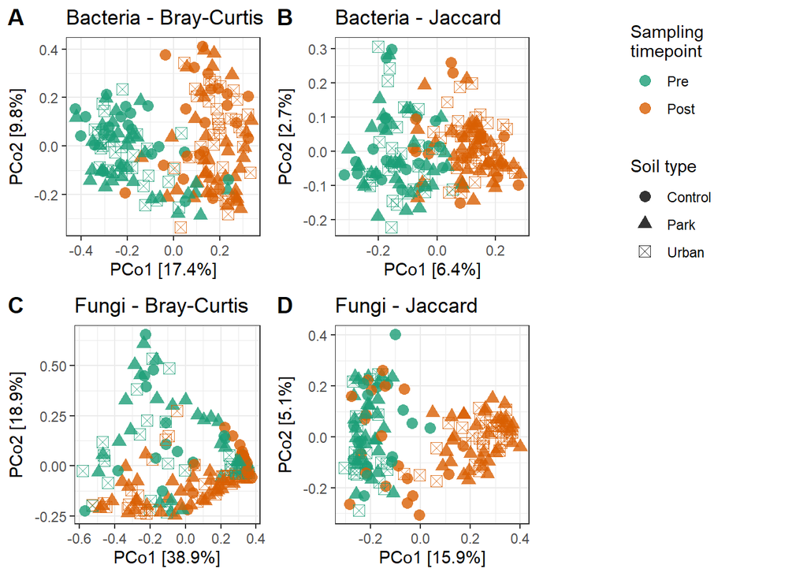

```r
p6 <- t1$plot_ordination(plot_color = "Sampling_timepoint", plot_shape = "Soil_type", plot_type = c("point")) +
  ggtitle("Fungi - Bray-Curtis") +
  theme_bw() +
  theme(legend.position = "none")


plot_grid(p2,p6,p1,p5,legend, byrow=FALSE, ncol=3, labels= c("A", "B", "", "C", "D"))
```

```r
ggsave("Fig_beta_all_time.png", width=10, height = 6, units = "in")
```

## T2 groups

```r
# T2

# Set data
dat1 <- clone(dsBFec) # Using  16S data for beta
dat1$sample_table <- dat1$sample_table %>% subset(Sampling_timepoint == "Post")
dat1$tidy_dataset()
```

```
## 503 taxa with 0 abundance are removed from the otu_table ...
```

```r
dat2 <- clone(dsFFec)
dat2$sample_table <- dat2$sample_table %>% subset(Sampling_timepoint == "Post")
dat2$tidy_dataset()
```

```
## 81 taxa with 0 abundance are removed from the otu_table ...
```

```r
# Get legend
t1 <- trans_beta$new(dataset = dat1, group = "Soil_type", measure = "bray")
t1$cal_ordination(method = "PCoA")
```

```
## The result is stored in object$res_ordination ...
```

```r
p1 <- t1$plot_ordination(plot_color = "Soil_type", plot_shape = "Soil_type", plot_type = c("point", "ellipse")) +
  labs(color="Soil type", shape="Soil type", fill="Soil type")
legend <- get_legend(p1)
# 16S
t1 <- trans_beta$new(dataset = dat1, group = "Soil_type", measure = "jaccard")
t1$cal_ordination(method = "PCoA")
```

```
## The result is stored in object$res_ordination ...
```

```r
p1 <- t1$plot_ordination(plot_color = "Soil_type", plot_shape = "Soil_type", plot_type = c("point", "ellipse")) +
  ggtitle("Bacteria - Jaccard") +
  theme_bw() +
  theme(legend.position = "none")

t1 <- trans_beta$new(dataset = dat1, group = "Soil_type", measure = "bray")
t1$cal_ordination(method = "PCoA")
```

```
## The result is stored in object$res_ordination ...
```

```r
p2 <- t1$plot_ordination(plot_color = "Soil_type", plot_shape = "Soil_type", plot_type = c("point", "ellipse")) +
  ggtitle("Bacteria - Bray-Curtis") +
  theme_bw() +
  theme(legend.position = "none")


# ITS2
t1 <- trans_beta$new(dataset = dat2, group = "Soil_type", measure = "jaccard")
t1$cal_ordination(method = "PCoA")
```

```
## The result is stored in object$res_ordination ...
```

```r
p5 <- t1$plot_ordination(plot_color = "Soil_type", plot_shape = "Soil_type", plot_type = c("point", "ellipse")) +
  ggtitle("Fungi - Jaccard") +
  theme_bw() +
  theme(legend.position = "none")

t1 <- trans_beta$new(dataset = dat2, group = "Soil_type", measure = "bray")
t1$cal_ordination(method = "PCoA")
```

```
## The result is stored in object$res_ordination ...
```

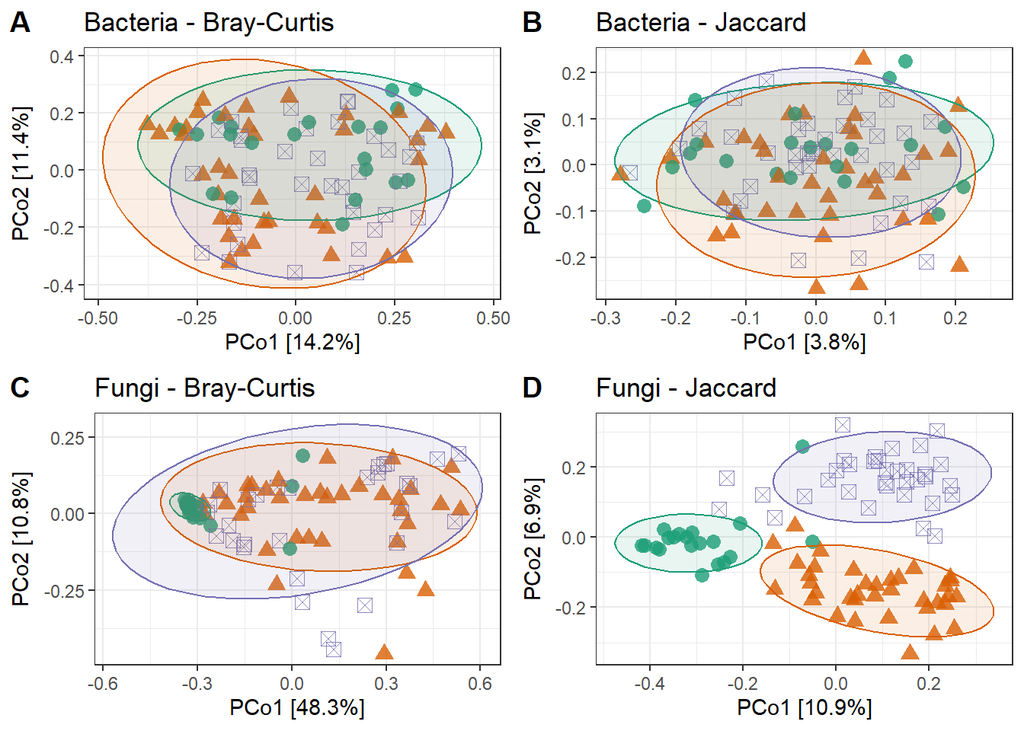

```r
p6 <- t1$plot_ordination(plot_color = "Soil_type", plot_shape = "Soil_type", plot_type = c("point", "ellipse")) +
  ggtitle("Fungi - Bray-Curtis") +
  theme_bw() +
  theme(legend.position = "none")


plot_grid(p2,p6,p1,p5, byrow=FALSE, ncol=2, labels= c("A", "B", "C", "D"))
```

```r
ggsave("Fig_beta_groups.png", width=8, height = 6, units = "in")
```

## T1 groups

```r
# T1

# Set data
dat1 <- clone(dsBFec)

dat1$sample_table <- dat1$sample_table %>% subset(Sampling_timepoint == "Pre")
dat1$tidy_dataset()
```

```
## 1263 taxa with 0 abundance are removed from the otu_table ...
```

```r
dat2 <- clone(dsFFec)
dat2$sample_table <- dat2$sample_table %>% subset(Sampling_timepoint == "Pre")
dat2$tidy_dataset()
```

```
## 721 taxa with 0 abundance are removed from the otu_table ...
```

```r
# Get legend
t1 <- trans_beta$new(dataset = dat1, group = "Soil_type", measure = "bray")
t1$cal_ordination(method = "PCoA")
```

```
## The result is stored in object$res_ordination ...
```

```r
p1 <- t1$plot_ordination(plot_color = "Soil_type", plot_shape = "Soil_type", plot_type = c("point", "ellipse")) +
  labs(color="Soil type", shape="Soil type", fill="Soil type")
legend <- get_legend(p1)
# 16S
t1 <- trans_beta$new(dataset = dat1, group = "Soil_type", measure = "jaccard")
t1$cal_ordination(method = "PCoA")
```

```
## The result is stored in object$res_ordination ...
```

```r
bjac <- t1$plot_ordination(plot_color = "Soil_type", plot_shape = "Soil_type", plot_type = c("point", "ellipse")) +
  ggtitle("Bacteria - Jaccard") +
  theme_bw() +
  theme(legend.position = "none")

t1 <- trans_beta$new(dataset = dat1, group = "Soil_type", measure = "bray")
t1$cal_ordination(method = "PCoA")
```

```
## The result is stored in object$res_ordination ...
```

```r
bbray <- t1$plot_ordination(plot_color = "Soil_type", plot_shape = "Soil_type", plot_type = c("point", "ellipse")) +
  ggtitle("Bacteria - Bray-Curtis") +
  theme_bw() +
  theme(legend.position = "none")


# ITS2
t1 <- trans_beta$new(dataset = dat2, group = "Soil_type", measure = "jaccard")
t1$cal_ordination(method = "PCoA")
```

```
## The result is stored in object$res_ordination ...
```

```r
fjac <- t1$plot_ordination(plot_color = "Soil_type", plot_shape = "Soil_type", plot_type = c("point", "ellipse")) +
  ggtitle("Fungi - Jaccard") +
  theme_bw() +
  theme(legend.position = "none")

t1 <- trans_beta$new(dataset = dat2, group = "Soil_type", measure = "bray")
t1$cal_ordination(method = "PCoA")
```

```
## The result is stored in object$res_ordination ...
```

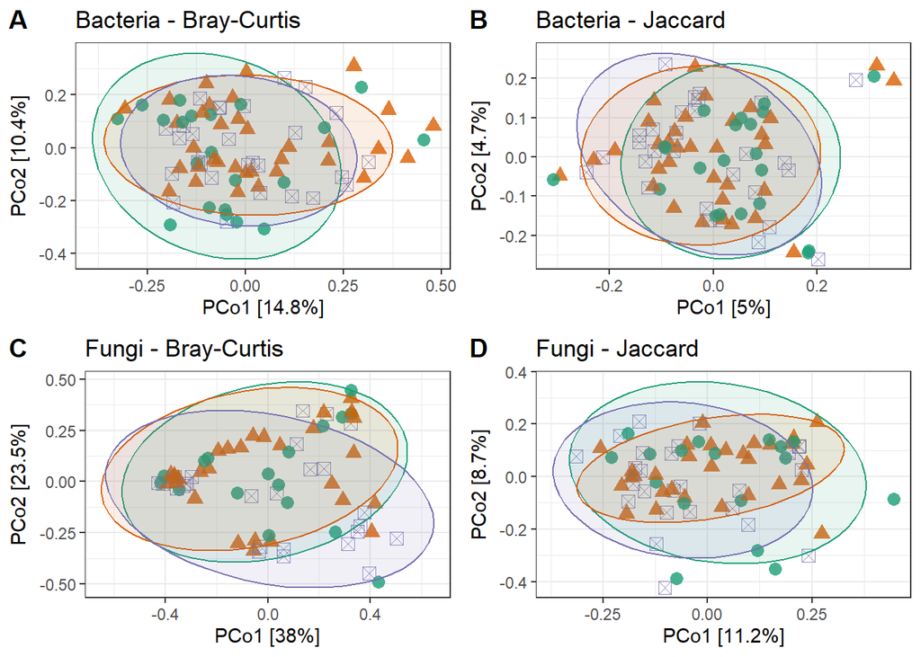

```r
fbray <- t1$plot_ordination(plot_color = "Soil_type", plot_shape = "Soil_type", plot_type = c("point", "ellipse")) +
  ggtitle("Fungi - Bray-Curtis") +
  theme_bw() +
  theme(legend.position = "none")


plot_grid(bbray, fbray, bjac, fjac, byrow=FALSE, ncol=2, labels= c("A", "B", "C", "D"))
```

```r
ggsave("Fig_beta_all_T1.png", width=8, height = 6, units = "in")
```

# Beta models

Extract distance matrices from microeco and model externally in vegan to keep things consistent.

## Fungi fullmodel - Bray

```r
# Define data
dat = dsFFec$sample_table
Dist = dsFFec$otu_table %>%
  t() %>%
  as.matrix() %>%
  vegdist(method = "bray")

# PERMANOVA

set.seed(42)
# Across groups
M1 <- adonis2(
  Dist ~ Sampling_timepoint + Soil_type, data = dat, by="margin") %>%
  rownames_to_column(., "Variable") %>%
  as_tibble() %>%
 mutate_if(is.numeric, round, digits=2)
M1
```

| Variable | Df | SumOfSqs | R2 | F | Pr(>F) |
| --- | --- | --- | --- | --- | --- |
| Sampling_timepoint | 1 | 2.25 | 0.07 | 13.14 | 0 |
| Soil_type | 2 | 1.59 | 0.05 | 4.63 | 0 |
| Residual | 159 | 27.27 | 0.88 | NA | NA |
| Total | 162 | 31.13 | 1.00 | NA | NA |

```r
# Pairwise
M2 <- pairwise.adonis2(
  Dist ~ Soil_type,
  data = dat,
  strata = 'Sampling_timepoint') # controls for timepoint
M2
```

```
## $parent_call
## [1] "Dist ~ Soil_type , strata = Sampling_timepoint , permutations 999"
##
## $Urban_vs_Control
##           Df SumOfSqs      R2      F Pr(>F)
## Soil_type  1   1.0839 0.05758 5.8043  0.002 **
## Residual  95  17.7405 0.94242
## Total     96  18.8244 1.00000
## ---
## Signif. codes:  0 '***' 0.001 '**' 0.01 '*' 0.05 '.' 0.1 ' ' 1
##
## $Urban_vs_Park
##            Df SumOfSqs      R2      F Pr(>F)
## Soil_type   1   0.4385 0.01827 2.3078  0.045 *
## Residual  124  23.5606 0.98173
## Total     125  23.9991 1.00000
## ---
## Signif. codes:  0 '***' 0.001 '**' 0.01 '*' 0.05 '.' 0.1 ' ' 1
##
## $Control_vs_Park
##            Df SumOfSqs     R2      F Pr(>F)
## Soil_type   1    0.972 0.0519 5.5291  0.001 ***
## Residual  101   17.756 0.9481
## Total     102   18.728 1.0000
## ---
## Signif. codes:  0 '***' 0.001 '**' 0.01 '*' 0.05 '.' 0.1 ' ' 1
##
## attr(,"class")
## [1] "pwadstrata" "list"
```

```r
# BETADISPER

# Across groups
M3 <- betadisper(
  Dist, group =  dat$Sampling_timepoint, bias.adjust = TRUE) %>%
  permutest() %>%
  .$tab %>%
  as.data.frame() %>%
  mutate_if(is.numeric, round, digits=2) %>%
  print()
```

```
##            Df Sum Sq Mean Sq    F N.Perm Pr(>F)
## Groups      1   0.18    0.18 6.01    999   0.02
## Residuals 161   4.69    0.03   NA     NA     NA
```

```r
# export tables
write.table(M1, file = "betares/ADONIS_fec_fungi_97clust_time_bray.txt", sep = "\t")
write.table(M2, file = "betares/ADONIS_fec_fungi_97clust_time_bray_pairwise.txt", sep = "\t")
write.table(M3, file = "betares/BETADISP_fec_fungi_97clust_time_bray.txt", sep = "\t")
```

## Fungi fullmodel - Jac

```r
# Define data
dat = dsFFec$sample_table
Dist = dsFFec$otu_table %>%
  t() %>%
  as.matrix() %>%
  vegdist(method = "jaccard")

# PERMANOVA

set.seed(42)
# Across groups
M1 <- adonis2(
  Dist ~ Sampling_timepoint + Soil_type, data = dat, by="margin") %>%
  rownames_to_column(., "Variable") %>%
  as_tibble() %>%
 mutate_if(is.numeric, round, digits=2)
M1
```

| Variable | Df | SumOfSqs | R2 | F | Pr(>F) |
| --- | --- | --- | --- | --- | --- |
| Sampling_timepoint | 1 | 2.07 | 0.05 | 8.45 | 0 |
| Soil_type | 2 | 1.87 | 0.04 | 3.82 | 0 |
| Residual | 159 | 38.98 | 0.91 | NA | NA |
| Total | 162 | 42.92 | 1.00 | NA | NA |

```r
# Pairwise
M2 <- pairwise.adonis2(
  Dist ~ Soil_type,
  data = dat,
  strata = 'Sampling_timepoint') # controls for timepoint
M2
```

```
## $parent_call
## [1] "Dist ~ Soil_type , strata = Sampling_timepoint , permutations 999"
##
## $Urban_vs_Control
##           Df SumOfSqs      R2      F Pr(>F)
## Soil_type  1   1.2253 0.04803 4.7932  0.002 **
## Residual  95  24.2862 0.95197
## Total     96  25.5115 1.00000
## ---
## Signif. codes:  0 '***' 0.001 '**' 0.01 '*' 0.05 '.' 0.1 ' ' 1
##
## $Urban_vs_Park
##            Df SumOfSqs      R2     F Pr(>F)
## Soil_type   1    0.550 0.01638 2.065  0.038 *
## Residual  124   33.013 0.98362
## Total     125   33.563 1.00000
## ---
## Signif. codes:  0 '***' 0.001 '**' 0.01 '*' 0.05 '.' 0.1 ' ' 1
##
## $Control_vs_Park
##            Df SumOfSqs      R2      F Pr(>F)
## Soil_type   1   1.1434 0.04408 4.6577  0.001 ***
## Residual  101  24.7938 0.95592
## Total     102  25.9372 1.00000
## ---
## Signif. codes:  0 '***' 0.001 '**' 0.01 '*' 0.05 '.' 0.1 ' ' 1
##
## attr(,"class")
## [1] "pwadstrata" "list"
```

```r
# BETADISPER

# Across groups
M3 <- betadisper(
  Dist, group =  dat$Sampling_timepoint, bias.adjust = TRUE) %>%
  permutest() %>%
  .$tab %>%
  as.data.frame() %>%
  mutate_if(is.numeric, round, digits=2) %>%
  print()
```

```
##            Df Sum Sq Mean Sq    F N.Perm Pr(>F)
## Groups      1   0.11    0.11 4.88    999   0.04
## Residuals 161   3.58    0.02   NA     NA     NA
```

```r
# export tables
write.table(M1, file = "betares/ADONIS_fec_fungi_97clust_time_jac.txt", sep = "\t")
write.table(M2, file = "betares/ADONIS_fec_fungi_97clust_time_jac_pairwise.txt", sep = "\t")
write.table(M3, file = "betares/BETADISP_fec_fungi_97clust_time_jac.txt", sep = "\t")
```

## Fungi T2 - Bray

Only betadisper analysis is relevant for paper. For permanova, results from full model are used.

```r
# Define data
dat = dsFFecT2$sample_table
Dist = dsFFecT2$otu_table %>%
  t() %>%
  as.matrix() %>%
  vegdist(method = "bray")

# PERMANOVA

set.seed(42)
# Across groups
M1 <- adonis2(
  Dist ~ Soil_type, data = dat, by="margin") %>%
  rownames_to_column(., "Variable") %>%
  as_tibble() %>%
  relocate(R2, .after = F) %>%
 mutate_if(is.numeric, round, digits=3)
M1
```

| Variable | Df | SumOfSqs | F | R2 | Pr(>F) |
| --- | --- | --- | --- | --- | --- |
| Soil_type | 2 | 2.698 | 10.374 | 0.193 | 0.001 |
| Residual | 87 | 11.313 | NA | 0.807 | NA |
| Total | 89 | 14.011 | NA | 1.000 | NA |

```r
# Pairwise PERMANOVA
M2 <- pairwise.adonis(
  Dist, dat$Soil_type, perm = 999, p.adjust.m = "fdr") %>%
  as_tibble()  %>%
  mutate_if(is.numeric, round, digits=3)
M2
```

| pairs | Df | SumsOfSqs | F.Model | R2 | p.value | p.adjusted | sig |
| --- | --- | --- | --- | --- | --- | --- | --- |
| Urban vs Control | 1 | 1.480 | 11.408 | 0.180 | 0.001 | 0.002 | * |
| Urban vs Park | 1 | 0.705 | 4.556 | 0.063 | 0.002 | 0.002 | * |
| Control vs Park | 1 | 2.028 | 20.444 | 0.275 | 0.001 | 0.002 | * |

```r
# BETADISPER

# Across groups
M3 <- betadisper(
  Dist, group =  dat$Soil_type, bias.adjust = TRUE) %>%
  permutest() %>%
  .$tab %>%
  as.data.frame() %>%
  mutate_if(is.numeric, round, digits=3) %>%
  print()
```

```
##           Df Sum Sq Mean Sq      F N.Perm Pr(>F)
## Groups     2  0.786   0.393 18.689    999  0.001
## Residuals 87  1.830   0.021     NA     NA     NA
```

```r
# Pairwise
M4 <- betadisper(
  Dist, group =  dat$Soil_type, bias.adjust = TRUE) %>%
  permutest(pairwise = TRUE)

M4 <- as.data.frame(
  M4$pairwise) %>%
  rownames_to_column(., var="comparison") %>%
  add_column(variable="Soil_type") %>%
  mutate_if(is.numeric, round, digits=3)
M4
```

| comparison | observed | permuted | variable |
| --- | --- | --- | --- |
| Control-Park | 0.000 | 0.001 | Soil_type |
| Control-Urban | 0.000 | 0.001 | Soil_type |
| Park-Urban | 0.048 | 0.050 | Soil_type |

```r
# export tables
write.table(M1, file = "betares/ADONIS_fec_fungi_97clust_T2_bray.txt", sep = "\t")
write.table(M2, file = "betares/ADONIS_fec_fungi_97clust_T2_bray_pairwise.txt",  sep = "\t")
write.table(M3, file = "betares/BETADISP_fec_fungi_97clust_T2_bray.txt", sep = "\t")
write.table(M4, file = "betares/BETADISP_fec_fungi_97clust_T2_bray_pairwise.txt", sep = "\t")
```

## Fungi T2 - Jac

Only betadisper analysis is relevant for paper. For permanova, results from full model are used.

```r
# Define data
dat = dsFFecT2$sample_table
Dist = dsFFecT2$otu_table %>%
  t() %>%
  as.matrix() %>%
  vegdist(method = "jaccard")

# PERMANOVA

set.seed(42)
# Across groups
M1 <- adonis2(
  Dist ~ Soil_type, data = dat, by="margin") %>%
  rownames_to_column(., "Variable") %>%
  as_tibble() %>%
  relocate(R2, .after = F) %>%
 mutate_if(is.numeric, round, digits=3)
M1
```

| Variable | Df | SumOfSqs | F | R2 | Pr(>F) |
| --- | --- | --- | --- | --- | --- |
| Soil_type | 2 | 3.181 | 7.894 | 0.154 | 0.001 |
| Residual | 87 | 17.527 | NA | 0.846 | NA |
| Total | 89 | 20.708 | NA | 1.000 | NA |

```r
# Pairwise PERMANOVA
M2 <- pairwise.adonis(
  Dist, dat$Soil_type, perm = 999, p.adjust.m = "fdr") %>%
  as_tibble()  %>%
  mutate_if(is.numeric, round, digits=3)
M2
```

| pairs | Df | SumsOfSqs | F.Model | R2 | p.value | p.adjusted | sig |
| --- | --- | --- | --- | --- | --- | --- | --- |
| Urban vs Control | 1 | 1.786 | 9.094 | 0.149 | 0.001 | 0.002 | * |
| Urban vs Park | 1 | 0.809 | 3.455 | 0.048 | 0.004 | 0.004 | * |
| Control vs Park | 1 | 2.379 | 14.399 | 0.211 | 0.001 | 0.002 | * |

```r
# BETADISPER

# Across groups
M3 <- betadisper(
  Dist, group =  dat$Soil_type, bias.adjust = TRUE) %>%
  permutest() %>%
  .$tab %>%
  as.data.frame() %>%
  mutate_if(is.numeric, round, digits=3) %>%
  print()
```

```
##           Df Sum Sq Mean Sq      F N.Perm Pr(>F)
## Groups     2  0.859    0.43 21.516    999  0.001
## Residuals 87  1.737    0.02     NA     NA     NA
```

```r
# Pairwise
M4 <- betadisper(
  Dist, group =  dat$Soil_type, bias.adjust = TRUE) %>%
  permutest(pairwise = TRUE)

M4 <- as.data.frame(
  M4$pairwise) %>%
  rownames_to_column(., var="comparison") %>%
  add_column(variable="Soil_type") %>%
  mutate_if(is.numeric, round, digits=3)
M4
```

| comparison | observed | permuted | variable |
| --- | --- | --- | --- |
| Control-Park | 0.00 | 0.001 | Soil_type |
| Control-Urban | 0.00 | 0.001 | Soil_type |
| Park-Urban | 0.06 | 0.064 | Soil_type |

```r
# export tables
write.table(M1, file = "betares/ADONIS_fec_fungi_97clust_T2_jac.txt", sep = "\t")
write.table(M2, file = "betares/ADONIS_fec_fungi_97clust_T2_jac_pairwise.txt",  sep = "\t")
write.table(M3, file = "betares/BETADISP_fec_fungi_97clust_T2_jac.txt", sep = "\t")
write.table(M4, file = "betares/BETADISP_fec_fungi_97clust_T2_jac_pairwise.txt", sep = "\t")
```

## Fungi T1 - Bray

```r
# Define data
dat = dsFFecT1$sample_table
Dist = dsFFecT1$otu_table %>%
  t() %>%
  as.matrix() %>%
  vegdist(method = "bray")

# PERMANOVA

set.seed(42)
# Across groups
M1 <- adonis2(
  Dist ~ Soil_type, data = dat, by="margin") %>%
  rownames_to_column(., "Variable") %>%
  as_tibble() %>%
  relocate(R2, .after = F) %>%
 mutate_if(is.numeric, round, digits=2)
M1
```

| Variable | Df | SumOfSqs | F | R2 | Pr(>F) |
| --- | --- | --- | --- | --- | --- |
| Soil_type | 2 | 0.36 | 0.86 | 0.02 | 0.54 |
| Residual | 70 | 14.50 | NA | 0.98 | NA |
| Total | 72 | 14.85 | NA | 1.00 | NA |

```r
# Pairwise PERMANOVA
M2 <- pairwise.adonis(
  Dist, dat$Soil_type, perm = 999, p.adjust.m = "fdr") %>%
  as_tibble()  %>%
  mutate_if(is.numeric, round, digits=2)
M2
```

| pairs | Df | SumsOfSqs | F.Model | R2 | p.value | p.adjusted | sig |
| --- | --- | --- | --- | --- | --- | --- | --- |
| Control vs Park | 1 | 0.08 | 0.39 | 0.01 | 0.90 | 0.90 |  |
| Control vs Urban | 1 | 0.17 | 0.78 | 0.02 | 0.56 | 0.85 |  |
| Park vs Urban | 1 | 0.27 | 1.36 | 0.02 | 0.25 | 0.75 |  |

```r
# BETADISPER

# Across groups
M3 <- betadisper(
  Dist, group =  dat$Soil_type, bias.adjust = TRUE) %>%
  permutest() %>%
  .$tab %>%
  as.data.frame() %>%
  mutate_if(is.numeric, round, digits=2) %>%
  print()
```

```
##           Df Sum Sq Mean Sq    F N.Perm Pr(>F)
## Groups     2   0.03    0.02 0.54    999   0.57
## Residuals 70   2.09    0.03   NA     NA     NA
```

```r
# Pairwise
M4 <- betadisper(
  Dist, group =  dat$Soil_type, bias.adjust = TRUE) %>%
  permutest(pairwise = TRUE)

M4 <- as.data.frame(
  M4$pairwise) %>%
  rownames_to_column(., var="comparison") %>%
  add_column(variable="Soil_type") %>%
  mutate_if(is.numeric, round, digits=2)
M4
```

| comparison | observed | permuted | variable |
| --- | --- | --- | --- |
| Control-Park | 0.35 | 0.34 | Soil_type |
| Control-Urban | 0.41 | 0.39 | Soil_type |
| Park-Urban | 0.83 | 0.82 | Soil_type |

```r
# export tables
write.table(M1, file = "betares/ADONIS_fec_fungi_97clust_T1_bray.txt", sep = "\t")
write.table(M2, file = "betares/ADONIS_fec_fungi_97clust_T1_bray_pairwise.txt",  sep = "\t")
write.table(M3, file = "betares/BETADISP_fec_fungi_97clust_T1_bray.txt", sep = "\t")
write.table(M4, file = "betares/BETADISP_fec_fungi_97clust_T1_bray_pairwise.txt", sep = "\t")
```

## Fungi - T1 Jac

```r
# Define data
dat = dsFFecT1$sample_table
Dist = dsFFecT1$otu_table %>%
  t() %>%
  as.matrix() %>%
  vegdist(method = "jaccard")

# PERMANOVA

set.seed(42)
# Across groups
M1 <- adonis2(
  Dist ~ Soil_type, data = dat, by="margin") %>%
  rownames_to_column(., "Variable") %>%
  as_tibble() %>%
  relocate(R2, .after = F) %>%
 mutate_if(is.numeric, round, digits=2)
M1
```

| Variable | Df | SumOfSqs | F | R2 | Pr(>F) |
| --- | --- | --- | --- | --- | --- |
| Soil_type | 2 | 0.48 | 0.86 | 0.02 | 0.59 |
| Residual | 70 | 19.66 | NA | 0.98 | NA |
| Total | 72 | 20.14 | NA | 1.00 | NA |

```r
# Pairwise PERMANOVA
M2 <- pairwise.adonis(
  Dist, dat$Soil_type, perm = 999, p.adjust.m = "fdr") %>%
  as_tibble()  %>%
  mutate_if(is.numeric, round, digits=2)
M2
```

| pairs | Df | SumsOfSqs | F.Model | R2 | p.value | p.adjusted | sig |
| --- | --- | --- | --- | --- | --- | --- | --- |
| Control vs Park | 1 | 0.14 | 0.51 | 0.01 | 0.94 | 0.94 |  |
| Control vs Urban | 1 | 0.22 | 0.77 | 0.02 | 0.63 | 0.94 |  |
| Park vs Urban | 1 | 0.34 | 1.25 | 0.02 | 0.26 | 0.77 |  |

```r
# BETADISPER

# Across groups
M3 <- betadisper(
  Dist, group =  dat$Soil_type, bias.adjust = TRUE) %>%
  permutest() %>%
  .$tab %>%
  as.data.frame() %>%
  mutate_if(is.numeric, round, digits=2) %>%
  print()
```

```
##           Df Sum Sq Mean Sq    F N.Perm Pr(>F)
## Groups     2   0.02    0.01 0.52    999   0.59
## Residuals 70   1.49    0.02   NA     NA     NA
```

```r
# Pairwise
M4 <- betadisper(
  Dist, group =  dat$Soil_type, bias.adjust = TRUE) %>%
  permutest(pairwise = TRUE)

M4 <- as.data.frame(
  M4$pairwise) %>%
  rownames_to_column(., var="comparison") %>%
  add_column(variable="Soil_type") %>%
  mutate_if(is.numeric, round, digits=2)
M4
```

| comparison | observed | permuted | variable |
| --- | --- | --- | --- |
| Control-Park | 0.36 | 0.35 | Soil_type |
| Control-Urban | 0.39 | 0.38 | Soil_type |
| Park-Urban | 0.84 | 0.86 | Soil_type |

```r
# export tables
write.table(M1, file = "betares/ADONIS_fec_fungi_97clust_T1_jac.txt", sep = "\t")
write.table(M2, file = "betares/ADONIS_fec_fungi_97clust_T1_jac_pairwise.txt",  sep = "\t")
write.table(M3, file = "betares/BETADISP_fec_fungi_97clust_T1_jac.txt", sep = "\t")
write.table(M4, file = "betares/BETADISP_fec_fungi_97clust_T1_jac_pairwise.txt", sep = "\t")
```

## Bacteria fullmodel - Bray

```r
# Define data
dat = dsBFec$sample_table
Dist = dsBFec$otu_table %>%
  t() %>%
  as.matrix() %>%
  vegdist(method = "bray")

# PERMANOVA

set.seed(42)
# Across groups
M1 <- adonis2(
  Dist ~ Sampling_timepoint + Soil_type, data = dat, by="margin") %>%
  rownames_to_column(., "Variable") %>%
  as_tibble() %>%
 mutate_if(is.numeric, round, digits=2)
M1
```

| Variable | Df | SumOfSqs | R2 | F | Pr(>F) |
| --- | --- | --- | --- | --- | --- |
| Sampling_timepoint | 1 | 6.35 | 0.13 | 26.18 | 0.00 |
| Soil_type | 2 | 0.76 | 0.02 | 1.57 | 0.03 |
| Residual | 176 | 42.66 | 0.86 | NA | NA |
| Total | 179 | 49.81 | 1.00 | NA | NA |

```r
# Pairwise
M2 <- pairwise.adonis2(
  Dist ~ Soil_type,
  data = dat,
  strata = 'Sampling_timepoint') # controls for timepoint
M2
```

```
## $parent_call
## [1] "Dist ~ Soil_type , strata = Sampling_timepoint , permutations 999"
##
## $Urban_vs_Control
##            Df SumOfSqs      R2      F Pr(>F)
## Soil_type   1   0.3694 0.01212 1.3009  0.083 .
## Residual  106  30.0999 0.98788
## Total     107  30.4693 1.00000
## ---
## Signif. codes:  0 '***' 0.001 '**' 0.01 '*' 0.05 '.' 0.1 ' ' 1
##
## $Urban_vs_Park
##            Df SumOfSqs      R2      F Pr(>F)
## Soil_type   1    0.315 0.00838 1.1499  0.149
## Residual  136   37.273 0.99162
## Total     137   37.588 1.00000
##
## $Control_vs_Park
##            Df SumOfSqs      R2      F Pr(>F)
## Soil_type   1   0.5231 0.01678 1.9115  0.009 **
## Residual  112  30.6484 0.98322
## Total     113  31.1715 1.00000
## ---
## Signif. codes:  0 '***' 0.001 '**' 0.01 '*' 0.05 '.' 0.1 ' ' 1
##
## attr(,"class")
## [1] "pwadstrata" "list"
```

```r
# BETADISPER

# Across groups
M3 <- betadisper(
  Dist, group =  dat$Sampling_timepoint, bias.adjust = TRUE) %>%
  permutest() %>%
  .$tab %>%
  as.data.frame() %>%
  mutate_if(is.numeric, round, digits=2) %>%
  print()
```

```
##            Df Sum Sq Mean Sq     F N.Perm Pr(>F)
## Groups      1   0.17    0.17 31.46    999      0
## Residuals 178   0.94    0.01    NA     NA     NA
```

```r
# export tables
write.table(M1, file = "betares/ADONIS_fec_bacteria_time_bray.txt", sep = "\t")
write.table(M2, file = "betares/ADONIS_fec_bacteria_time_bray_pairwise.txt", sep = "\t")
write.table(M3, file = "betares/BETADISP_fec_bacteria_time_bray.txt", sep = "\t")
```

## Bacteria fullmodel - Jac

```r
# Define data
dat = dsBFec$sample_table
Dist = dsBFec$otu_table %>%
  t() %>%
  as.matrix() %>%
  vegdist(method = "jaccard")

# PERMANOVA

set.seed(42)
# Across groups
M1 <- adonis2(
  Dist ~ Sampling_timepoint + Soil_type, data = dat, by="margin") %>%
  rownames_to_column(., "Variable") %>%
  as_tibble() %>%
 mutate_if(is.numeric, round, digits=2)
M1
```

| Variable | Df | SumOfSqs | R2 | F | Pr(>F) |
| --- | --- | --- | --- | --- | --- |
| Sampling_timepoint | 1 | 5.18 | 0.08 | 15.68 | 0.00 |
| Soil_type | 2 | 0.85 | 0.01 | 1.29 | 0.05 |
| Residual | 176 | 58.16 | 0.91 | NA | NA |
| Total | 179 | 64.22 | 1.00 | NA | NA |

```r
# Pairwise
M2 <- pairwise.adonis2(
  Dist ~ Soil_type,
  data = dat,
  strata = 'Sampling_timepoint') # controls for timepoint
M2
```

```
## $parent_call
## [1] "Dist ~ Soil_type , strata = Sampling_timepoint , permutations 999"
##
## $Urban_vs_Control
##            Df SumOfSqs      R2      F Pr(>F)
## Soil_type   1    0.420 0.01077 1.1545  0.123
## Residual  106   38.544 0.98923
## Total     107   38.964 1.00000
##
## $Urban_vs_Park
##            Df SumOfSqs      R2     F Pr(>F)
## Soil_type   1    0.367 0.00754 1.033   0.22
## Residual  136   48.350 0.99246
## Total     137   48.717 1.00000
##
## $Control_vs_Park
##            Df SumOfSqs      R2      F Pr(>F)
## Soil_type   1    0.543 0.01345 1.5272  0.013 *
## Residual  112   39.788 0.98655
## Total     113   40.331 1.00000
## ---
## Signif. codes:  0 '***' 0.001 '**' 0.01 '*' 0.05 '.' 0.1 ' ' 1
##
## attr(,"class")
## [1] "pwadstrata" "list"
```

```r
# BETADISPER

# Across groups
M3 <- betadisper(
  Dist, group =  dat$Sampling_timepoint, bias.adjust = TRUE) %>%
  permutest() %>%
  .$tab %>%
  as.data.frame() %>%
  mutate_if(is.numeric, round, digits=2) %>%
  print()
```

```
##            Df Sum Sq Mean Sq     F N.Perm Pr(>F)
## Groups      1   0.08    0.08 31.21    999      0
## Residuals 178   0.48    0.00    NA     NA     NA
```

```r
# export tables
write.table(M1, file = "betares/ADONIS_fec_bacteria_time_jac.txt", sep = "\t")
write.table(M2, file = "betares/ADONIS_fec_bacteria_time_jac_pairwise.txt", sep = "\t")
write.table(M3, file = "betares/BETADISP_fec_bacteria_time_jac.txt", sep = "\t")
```

## Bacteria T2 - Bray

```r
# Define data
dat = dsBFecT2$sample_table
Dist = dsBFecT2$otu_table %>%
  t() %>%
  as.matrix() %>%
  vegdist(method = "bray")

# PERMANOVA

set.seed(42)
# Across groups
M1 <- adonis2(
  Dist ~ Soil_type, data = dat, by="margin") %>%
  rownames_to_column(., "Variable") %>%
  as_tibble() %>%
  relocate(R2, .after = F) %>%
 mutate_if(is.numeric, round, digits=3)
M1
```

| Variable | Df | SumOfSqs | F | R2 | Pr(>F) |
| --- | --- | --- | --- | --- | --- |
| Soil_type | 2 | 0.807 | 1.498 | 0.031 | 0.023 |
| Residual | 93 | 25.038 | NA | 0.969 | NA |
| Total | 95 | 25.845 | NA | 1.000 | NA |

```r
# Pairwise PERMANOVA
M2 <- pairwise.adonis(
  Dist, dat$Soil_type, perm = 999, p.adjust.m = "fdr") %>%
  as_tibble()  %>%
  mutate_if(is.numeric, round, digits=3)
M2
```

| pairs | Df | SumsOfSqs | F.Model | R2 | p.value | p.adjusted | sig |
| --- | --- | --- | --- | --- | --- | --- | --- |
| Urban vs Control | 1 | 0.354 | 1.270 | 0.022 | 0.157 | 0.157 |  |
| Urban vs Park | 1 | 0.462 | 1.749 | 0.023 | 0.027 | 0.081 |  |
| Control vs Park | 1 | 0.377 | 1.415 | 0.024 | 0.102 | 0.153 |  |

```r
# BETADISPER

# Across groups
M3 <- betadisper(
  Dist, group =  dat$Soil_type, bias.adjust = TRUE) %>%
  permutest() %>%
  .$tab %>%
  as.data.frame() %>%
  mutate_if(is.numeric, round, digits=3) %>%
  print()
```

```
##           Df Sum Sq Mean Sq     F N.Perm Pr(>F)
## Groups     2  0.018   0.009 1.521    999  0.218
## Residuals 93  0.556   0.006    NA     NA     NA
```

```r
# Pairwise
M4 <- betadisper(
  Dist, group =  dat$Soil_type, bias.adjust = TRUE) %>%
  permutest(pairwise = TRUE)

M4 <- as.data.frame(
  M4$pairwise) %>%
  rownames_to_column(., var="comparison") %>%
  add_column(variable="Soil_type") %>%
  mutate_if(is.numeric, round, digits=3)
M4
```

| comparison | observed | permuted | variable |
| --- | --- | --- | --- |
| Control-Park | 0.123 | 0.111 | Soil_type |
| Control-Urban | 0.484 | 0.488 | Soil_type |
| Park-Urban | 0.252 | 0.267 | Soil_type |

```r
# export tables
write.table(M1, file = "betares/ADONIS_fec_bacteria_T2_bray.txt", sep = "\t")
write.table(M2, file = "betares/ADONIS_fec_bacteria_T2_bray_pairwise.txt",  sep = "\t")
write.table(M3, file = "betares/BETADISP_fec_bacteria_T2_bray.txt", sep = "\t")
write.table(M4, file = "betares/BETADISP_fec_bacteria_T2_bray_pairwise.txt", sep = "\t")
```

## Bacteria T2 - Jac

```r
# Define data
dat = dsBFecT2$sample_table
Dist = dsBFecT2$otu_table %>%
  t() %>%
  as.matrix() %>%
  vegdist(method = "jaccard")

# PERMANOVA

set.seed(42)
# Across groups
M1 <- adonis2(
  Dist ~ Soil_type, data = dat, by="margin") %>%
  rownames_to_column(., "Variable") %>%
  as_tibble() %>%
  relocate(R2, .after = F) %>%
 mutate_if(is.numeric, round, digits=3)
M1
```

| Variable | Df | SumOfSqs | F | R2 | Pr(>F) |
| --- | --- | --- | --- | --- | --- |
| Soil_type | 2 | 0.906 | 1.285 | 0.027 | 0.029 |
| Residual | 93 | 32.781 | NA | 0.973 | NA |
| Total | 95 | 33.687 | NA | 1.000 | NA |

```r
# Pairwise PERMANOVA
M2 <- pairwise.adonis(
  Dist, dat$Soil_type, perm = 999, p.adjust.m = "fdr") %>%
  as_tibble()  %>%
  mutate_if(is.numeric, round, digits=3)
M2
```

| pairs | Df | SumsOfSqs | F.Model | R2 | p.value | p.adjusted | sig |
| --- | --- | --- | --- | --- | --- | --- | --- |
| Urban vs Control | 1 | 0.414 | 1.149 | 0.020 | 0.186 | 0.186 |  |
| Urban vs Park | 1 | 0.485 | 1.391 | 0.019 | 0.045 | 0.122 |  |
| Control vs Park | 1 | 0.451 | 1.290 | 0.022 | 0.081 | 0.122 |  |

```r
# BETADISPER

# Across groups
M3 <- betadisper(
  Dist, group =  dat$Soil_type, bias.adjust = TRUE) %>%
  permutest() %>%
  .$tab %>%
  as.data.frame() %>%
  mutate_if(is.numeric, round, digits=3) %>%
  print()
```

```
##           Df Sum Sq Mean Sq     F N.Perm Pr(>F)
## Groups     2  0.009   0.005 1.669    999  0.182
## Residuals 93  0.262   0.003    NA     NA     NA
```

```r
# Pairwise
M4 <- betadisper(
  Dist, group =  dat$Soil_type, bias.adjust = TRUE) %>%
  permutest(pairwise = TRUE)

M4 <- as.data.frame(
  M4$pairwise) %>%
  rownames_to_column(., var="comparison") %>%
  add_column(variable="Soil_type") %>%
  mutate_if(is.numeric, round, digits=3)
M4
```

| comparison | observed | permuted | variable |
| --- | --- | --- | --- |
| Control-Park | 0.112 | 0.099 | Soil_type |
| Control-Urban | 0.489 | 0.498 | Soil_type |
| Park-Urban | 0.220 | 0.238 | Soil_type |

```r
# export tables
write.table(M1, file = "betares/ADONIS_fec_bacteria_T2_jac.txt", sep = "\t")
write.table(M2, file = "betares/ADONIS_fec_bacteria_T2_jac_pairwise.txt",  sep = "\t")
write.table(M3, file = "betares/BETADISP_fec_bacteria_T2_jac.txt", sep = "\t")
write.table(M4, file = "betares/BETADISP_fec_bacteria_T2_jac_pairwise.txt", sep = "\t")
```

## Bacteria T1 - Bray

```r
# Define data
dat = dsBFecT1$sample_table
Dist = dsBFecT1$otu_table %>%
  t() %>%
  as.matrix() %>%
  vegdist(method = "bray")

# PERMANOVA

set.seed(42)
# Across groups
M1 <- adonis2(
  Dist ~ Soil_type, data = dat, by="margin") %>%
  rownames_to_column(., "Variable") %>%
  as_tibble() %>%
  relocate(R2, .after = F) %>%
 mutate_if(is.numeric, round, digits=2)
M1
```

| Variable | Df | SumOfSqs | F | R2 | Pr(>F) |
| --- | --- | --- | --- | --- | --- |
| Soil_type | 2 | 0.47 | 1.1 | 0.03 | 0.31 |
| Residual | 81 | 17.11 | NA | 0.97 | NA |
| Total | 83 | 17.58 | NA | 1.00 | NA |

```r
# Pairwise PERMANOVA
M2 <- pairwise.adonis(
  Dist, dat$Soil_type, perm = 999, p.adjust.m = "fdr") %>%
  as_tibble()  %>%
  mutate_if(is.numeric, round, digits=2)
M2
```

| pairs | Df | SumsOfSqs | F.Model | R2 | p.value | p.adjusted | sig |
| --- | --- | --- | --- | --- | --- | --- | --- |
| Control vs Park | 1 | 0.33 | 1.53 | 0.03 | 0.09 | 0.19 |  |
| Control vs Urban | 1 | 0.29 | 1.38 | 0.03 | 0.13 | 0.19 |  |
| Park vs Urban | 1 | 0.10 | 0.50 | 0.01 | 0.96 | 0.96 |  |

```r
# BETADISPER

# Across groups
M3 <- betadisper(
  Dist, group =  dat$Soil_type, bias.adjust = TRUE) %>%
  permutest() %>%
  .$tab %>%
  as.data.frame() %>%
  mutate_if(is.numeric, round, digits=2) %>%
  print()
```

```
##           Df Sum Sq Mean Sq    F N.Perm Pr(>F)
## Groups     2   0.00    0.00 0.45    999   0.62
## Residuals 81   0.41    0.01   NA     NA     NA
```

```r
# Pairwise
M4 <- betadisper(
  Dist, group =  dat$Soil_type, bias.adjust = TRUE) %>%
  permutest(pairwise = TRUE)

M4 <- as.data.frame(
  M4$pairwise) %>%
  rownames_to_column(., var="comparison") %>%
  add_column(variable="Soil_type") %>%
  mutate_if(is.numeric, round, digits=2)
M4
```

| comparison | observed | permuted | variable |
| --- | --- | --- | --- |
| Control-Park | 0.40 | 0.41 | Soil_type |
| Control-Urban | 0.40 | 0.41 | Soil_type |
| Park-Urban | 0.92 | 0.93 | Soil_type |

```r
# export tables
write.table(M1, file = "betares/ADONIS_fec_bacteria_T1_bray.txt", sep = "\t")
write.table(M2, file = "betares/ADONIS_fec_bacteria_T1_bray_pairwise.txt",  sep = "\t")
write.table(M3, file = "betares/BETADISP_fec_bacteria_T1_bray.txt", sep = "\t")
write.table(M4, file = "betares/BETADISP_fec_bacteria_T1_bray_pairwise.txt", sep = "\t")
```

## Bacteria T1 - Jac

```r
# Define data
dat = dsBFecT1$sample_table
Dist = dsBFecT1$otu_table %>%
  t() %>%
  as.matrix() %>%
  vegdist(method = "jaccard")

# PERMANOVA

set.seed(42)
# Across groups
M1 <- adonis2(
  Dist ~ Soil_type, data = dat, by="margin") %>%
  rownames_to_column(., "Variable") %>%
  as_tibble() %>%
  relocate(R2, .after = F) %>%
 mutate_if(is.numeric, round, digits=2)
M1
```

| Variable | Df | SumOfSqs | F | R2 | Pr(>F) |
| --- | --- | --- | --- | --- | --- |
| Soil_type | 2 | 0.64 | 1.04 | 0.03 | 0.37 |
| Residual | 81 | 24.69 | NA | 0.97 | NA |
| Total | 83 | 25.33 | NA | 1.00 | NA |

```r
# Pairwise PERMANOVA
M2 <- pairwise.adonis(
  Dist, dat$Soil_type, perm = 999, p.adjust.m = "fdr") %>%
  as_tibble()  %>%
  mutate_if(is.numeric, round, digits=2)
M2
```

| pairs | Df | SumsOfSqs | F.Model | R2 | p.value | p.adjusted | sig |
| --- | --- | --- | --- | --- | --- | --- | --- |
| Control vs Park | 1 | 0.40 | 1.31 | 0.02 | 0.11 | 0.22 |  |
| Control vs Urban | 1 | 0.38 | 1.23 | 0.02 | 0.15 | 0.22 |  |
| Park vs Urban | 1 | 0.20 | 0.66 | 0.01 | 0.97 | 0.97 |  |

```r
# BETADISPER

# Across groups
M3 <- betadisper(
  Dist, group =  dat$Soil_type, bias.adjust = TRUE) %>%
  permutest() %>%
  .$tab %>%
  as.data.frame() %>%
  mutate_if(is.numeric, round, digits=2) %>%
  print()
```

```
##           Df Sum Sq Mean Sq    F N.Perm Pr(>F)
## Groups     2   0.00       0 0.39    999   0.66
## Residuals 81   0.24       0   NA     NA     NA
```

```r
# Pairwise
M4 <- betadisper(
  Dist, group =  dat$Soil_type, bias.adjust = TRUE) %>%
  permutest(pairwise = TRUE)

M4 <- as.data.frame(
  M4$pairwise) %>%
  rownames_to_column(., var="comparison") %>%
  add_column(variable="Soil_type") %>%
  mutate_if(is.numeric, round, digits=2)
M4
```

| comparison | observed | permuted | variable |
| --- | --- | --- | --- |
| Control-Park | 0.42 | 0.42 | Soil_type |
| Control-Urban | 0.44 | 0.46 | Soil_type |
| Park-Urban | 0.90 | 0.91 | Soil_type |

```r
# export tables
write.table(M1, file = "betares/ADONIS_fec_bacteria_T1_jac.txt", sep = "\t")
write.table(M2, file = "betares/ADONIS_fec_bacteria_T1_jac_pairwise.txt",  sep = "\t")
write.table(M3, file = "betares/BETADISP_fec_bacteria_T1_jac.txt", sep = "\t")
write.table(M4, file = "betares/BETADISP_fec_bacteria_T1_jac_pairwise.txt", sep = "\t")
```

# First distances

First distances were calculated in q2-longitude plugin in QIIME 2 and data were extracted from the artifacts using QIIME2View (https://view.qiime2.org/).

## Plot

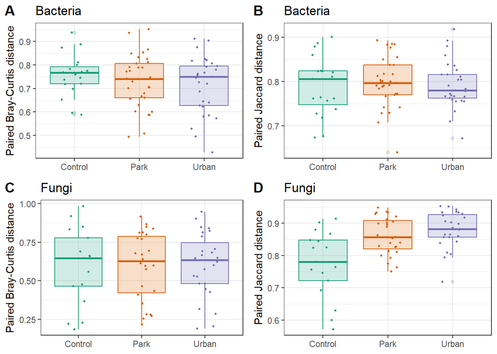

```r
dat1 <- read.table("betares/firstdistances_bacteria_jaccard.tsv", header = TRUE, sep = "\t")
p1 <- ggplot(dat1, aes(x = Group, y = Distance, color = Group)) +
  geom_boxplot(aes(fill=Group), alpha=0.2) +
  geom_jitter(position = position_jitterdodge(), size=0.8) +
  theme_bw() +
  scale_color_brewer(type = "qual", palette = "Dark2") +
  scale_fill_brewer(type = "qual", palette = "Dark2") +
  labs(title = "Bacteria",
       color="Soil type",
       fill = "Soil type",
       y = "Paired Jaccard distance") +
  theme(axis.title.x=element_blank(),
        legend.position = "none"
        )

dat2 <- read.table("betares/firstdistances_bacteria_bray.tsv", header = TRUE, sep = "\t")
p2 <- ggplot(dat2, aes(x = Group, y = Distance, color = Group)) +
  geom_boxplot(aes(fill=Group), alpha=0.2) +
  geom_jitter(position = position_jitterdodge(), size=0.8) +
  theme_bw() +
  scale_color_brewer(type = "qual", palette = "Dark2") +
  scale_fill_brewer(type = "qual", palette = "Dark2") +
  labs(title = "Bacteria",
       color="Soil type",
       fill = "Soil type",
       y = "Paired Bray-Curtis distance") +
  theme(axis.title.x=element_blank(),
        legend.position = "none"
        )

dat3 <- read.table("betares/firstdistances_fungi_jaccard.tsv", header = TRUE, sep = "\t")
p3 <- ggplot(dat3, aes(x = Group, y = Distance, color = Group)) +
  geom_boxplot(aes(fill=Group), alpha=0.2) +
  geom_jitter(position = position_jitterdodge(), size=0.8) +
  theme_bw() +
  scale_color_brewer(type = "qual", palette = "Dark2") +
  scale_fill_brewer(type = "qual", palette = "Dark2") +
  labs(title = "Fungi",
       color="Soil type",
       fill = "Soil type",
       y = "Paired Jaccard distance") +
  theme(axis.title.x=element_blank(),
        legend.position = "none"
        )

dat4 <- read.table("betares/firstdistances_fungi_bray.tsv", header = TRUE, sep = "\t")
p4 <- ggplot(dat4, aes(x = Group, y = Distance, color = Group)) +
  geom_boxplot(aes(fill=Group), alpha=0.2) +
  geom_jitter(position = position_jitterdodge(), size=0.8) +
  theme_bw() +
  scale_color_brewer(type = "qual", palette = "Dark2") +
  scale_fill_brewer(type = "qual", palette = "Dark2") +
  labs(title = "Fungi",
       color="Soil type",
       fill = "Soil type",
       y = "Paired Bray-Curtis distance") +
  theme(axis.title.x=element_blank(),
        legend.position = "none"
        )

plot_grid(p2,p1, p4, p3, labels = "AUTO")
```

```r
ggsave("Figure_firstdist.png", width=6, height = 5, units = "in")
```

## Model

```r
library(dplyr)
library(rstatix)

# Run Kruskal-Wallis tests
kruskal_list <- list(
  dat1 = kruskal.test(Distance ~ Group, dat1), # bacteria jac
  dat2 = kruskal.test(Distance ~ Group, dat2), # bacteria bray
  dat3 = kruskal.test(Distance ~ Group, dat3), # fungi jac
  dat4 = kruskal.test(Distance ~ Group, dat4)  # fungi bray
)

# Coerce to a summary data frame
kruskal_summary <- bind_rows(lapply(names(kruskal_list), function(name) {
  res <- kruskal_list[[name]]
  data.frame(
    dataset = name,
    statistic = unname(res$statistic),
    parameter = unname(res$parameter),
    p_value = res$p.value,
    method = res$method,
    stringsAsFactors = FALSE
  )
}))

# run pairwise Wilcoxon test for dat3 as it was significant
pairwise_wilcox <- dat3 %>%
  pairwise_wilcox_test(Distance ~ Group) %>%
  mutate(dataset = "dat3") %>%
  select(dataset, group1, group2, p, p.adj, p.adj.signif)

kruskal_summary
```

| dataset | statistic | parameter | p_value | method |
| --- | --- | --- | --- | --- |
| dat1 | 0.50174252 | 2 | 0.7781225390 | Kruskal-Wallis rank sum test |
| dat2 | 0.98007409 | 2 | 0.6126036991 | Kruskal-Wallis rank sum test |
| dat3 | 14.18517525 | 2 | 0.0008312436 | Kruskal-Wallis rank sum test |
| dat4 | 0.02029315 | 2 | 0.9899047298 | Kruskal-Wallis rank sum test |

```r
pairwise_wilcox
```

| dataset | group1 | group2 | p | p.adj | p.adj.signif |
| --- | --- | --- | --- | --- | --- |
| dat3 | Control | Park | 0.005000 | 0.009 | ** |
| dat3 | Control | Urban | 0.000377 | 0.001 | ** |
| dat3 | Park | Urban | 0.174000 | 0.174 | ns |

```r
# Write results to file
write.table(kruskal_summary, file = "firstdistances_kruskal_results.txt", sep = "\t", row.names = FALSE)
write.table(pairwise_wilcox, file = "firstdistances_pairwise_wilcox_fungijaccard.txt", sep = "\t", row.names = FALSE)
```